# Project: Identify Customer Segments

### Step 1.2: Select and Re-Encode Features

Checking for missing data isn't the only way in which you can prepare a dataset for analysis. Since the unsupervised learning techniques to be used will only work on data that is encoded numerically, you need to make a few encoding changes or additional assumptions to be able to make progress. In addition, while almost all of the values in the dataset are encoded using numbers, not all of them represent numeric values. Check the third column of the feature summary (`feat_info`) for a summary of types of measurement.

- For numeric and interval data, these features can be kept without changes.
- Most of the variables in the dataset are ordinal in nature. While ordinal values may technically be non-linear in spacing, make the simplifying assumption that the ordinal variables can be treated as being interval in nature (that is, kept without any changes).
- Special handling may be necessary for the remaining two variable types: categorical, and 'mixed'.

In the first two parts of this sub-step, you will perform an investigation of the categorical and mixed-type features and make a decision on each of them, whether you will keep, drop, or re-encode each. Then, in the last part, you will create a new data frame with only the selected and engineered columns.

Data wrangling is often the trickiest part of the data analysis process, and there's a lot of it to be done here. But stick with it: once you're done with this step, you'll be ready to get to the machine learning parts of the project!

### Finding types of columns

```python
# How many features are there of each data type?
col_type = feat_info_new['type'].value_counts()
col_type
```

```
ordinal        49
categorical    18
mixed           6
numeric         6
Name: type, dtype: int64
```

```python
categ_table = feat_info_new.loc[feat_info_new['type']=='categorical']
categ_table
```

|  | attribute | information_level | type | missing_or_unknown |
| --- | --- | --- | --- | --- |
| 2 | ANREDE_KZ | person | categorical | [-1, 0] |
| 3 | CJT_GESAMTTYP | person | categorical | [0] |
| 10 | FINANZTYP | person | categorical | [-1] |
| 12 | GFK_URLAUBERTYP | person | categorical | [] |
| 13 | GREEN_AVANTGARDE | person | categorical | [] |
| 17 | LP_FAMILIE_FEIN | person | categorical | [0] |
| 18 | LP_FAMILIE_GROB | person | categorical | [0] |
| 19 | LP_STATUS_FEIN | person | categorical | [0] |
| 20 | LP_STATUS_GROB | person | categorical | [0] |
| 21 | NATIONALITAET_KZ | person | categorical | [-1, 0] |
| 38 | SHOPPER_TYP | person | categorical | [-1] |
| 39 | SOHO_KZ | person | categorical | [-1] |
| 41 | VERS_TYP | person | categorical | [-1] |
| 42 | ZABEOTYP | person | categorical | [-1, 9] |
| 52 | GEBAEUDETYP | building | categorical | [-1, 0] |
| 55 | OST_WEST_KZ | building | categorical | [-1] |
| 57 | CAMEO_DEUG_2015 | microcell_rr4 | categorical | [-1, X] |
| 58 | CAMEO_DEU_2015 | microcell_rr4 | categorical | [XX] |

```python
mixed_table = feat_info_new.loc[feat_info_new['type']=='mixed']
mixed_table
```

|  | attribute | information_level | type | missing_or_unknown |
| --- | --- | --- | --- | --- |
| 15 | LP_LEBENSPHASE_FEIN | person | mixed | [0] |
| 16 | LP_LEBENSPHASE_GROB | person | mixed | [0] |
| 22 | PRAEGENDE_JUGENDJAHRE | person | mixed | [-1, 0] |
| 56 | WOHNLAGE | building | mixed | [-1] |
| 59 | CAMEO_INTL_2015 | microcell_rr4 | mixed | [-1, XX] |
| 79 | PLZ8_BAUMAX | macrocell_plz8 | mixed | [-1, 0] |

```python
numeric_table = feat_info_new.loc[feat_info_new['type']=='numeric']
numeric_table
```

|  | attribute | information_level | type | missing_or_unknown |
| --- | --- | --- | --- | --- |
| 44 | ANZ_PERSONEN | household | numeric | [] |
| 45 | ANZ_TITEL | household | numeric | [] |
| 50 | ANZ_HAUSHALTE_AKTIV | building | numeric | [0] |
| 51 | ANZ_HH_TITEL | building | numeric | [] |
| 54 | MIN_GEBAEUDEJAHR | building | numeric | [0] |
| 74 | KBA13_ANZAHL_PKW | macrocell_plz8 | numeric | [] |

```python
categ_cols = categ_table['attribute'].values
```

#### Step 1.2.1: Re-Encode Categorical Features

For categorical data, you would ordinarily need to encode the levels as dummy variables. Depending on the number of categories, perform one of the following:

- For binary (two-level) categoricals that take numeric values, you can keep them without needing to do anything.
- There is one binary variable that takes on non-numeric values. For this one, you need to re-encode the values as numbers or create a dummy variable.
- For multi-level categoricals (three or more values), you can choose to encode the values using multiple dummy variables (e.g. via [OneHotEncoder](http://scikit-learn.org/stable/modules/generated/sklearn.preprocessing.OneHotEncoder.html)), or (to keep things straightforward) just drop them from the analysis. As always, document your choices in the Discussion section.

```python
categ_dict ={}
for i in categ_table['attribute']:
    categ_dict[i] = data[i].value_counts()
categ_dict
```

```
{'ANREDE_KZ': 2.0    465305
 1.0    425916
 Name: ANREDE_KZ, dtype: int64, 'CJT_GESAMTTYP': 4.0    210963
 3.0    156449
 6.0    153915
 2.0    148795
 5.0    117376
 1.0     98869
 Name: CJT_GESAMTTYP, dtype: int64, 'FINANZTYP': 6.0    290367
 1.0    199572
 4.0    130625
 2.0    110867
 5.0    106436
 3.0     53354
 Name: FINANZTYP, dtype: int64, 'GFK_URLAUBERTYP': 12.0    138545
 5.0     120126
 10.0    109127
 8.0      88042
 11.0     79740
 4.0      63770
 9.0      60614
 3.0      56007
 1.0      53600
 2.0      46702
 7.0      42956
 6.0      27138
 Name: GFK_URLAUBERTYP, dtype: int64, 'GREEN_AVANTGARDE': 0    715996
 1    175225
 Name: GREEN_AVANTGARDE, dtype: int64, 'LP_FAMILIE_FEIN': 1.0     426379
 10.0    137913
 2.0     104305
 11.0     51719
 8.0      23032
 7.0      20730
 4.0      12303
 5.0      11920
 9.0      11148
 6.0       9022
 3.0       4958
 Name: LP_FAMILIE_FEIN, dtype: int64, 'LP_FAMILIE_GROB': 1.0    426379
```

[output cut: 84 more lines]

```
 4D     8570
 3B     7160
 6A     6810
 9E     6379
 6D     6073
 6F     5392
 7D     5333
 4E     5321
 1E     5065
 7E     4633
 1C     4317
 5F     4283
 1B     4071
 5E     3581
 Name: CAMEO_DEU_2015, dtype: int64}
```

```python
len(categ_dict)
```

```
18
```

### Assess categorical variables: which are binary, which are multi-level, and which one needs to be re-encoded?

### ['ANREDE_KZ', 'GREEN_AVANTGARDE', 'SOHO_KZ', 'VERS_TYP' ] columns have binary level numeric categories.

### ['OST_WEST_KZ'] column has binary level non-numeric categories - 'O' and 'W' - As this column is a binary category, if OneHot encoded we'll run into Dummy variable trap, hence to be manually encoded.

```
#### Supporting info link - https://www.algosome.com/articles/dummy-variable-trap-regression.html
```

### and other columns have multiple categorical values. These multi-categorical values are one-hot encoded.

```python
null_drop_row['OST_WEST_KZ'].value_counts()
```

```
W    628987
O    168439
Name: OST_WEST_KZ, dtype: int64
```

```python
# Manually encoding OST_WEST_KZ column
ost_west = {"W": 1, "O": 0}
null_drop_row['OST_WEST_KZ'] = null_drop_row['OST_WEST_KZ'].map(ost_west)
```

### OneHot Encoding of categorical columns

```python
# Selecting the columns to do OneHotEncoding
categ_cols_to_dummy = ['CJT_GESAMTTYP', 'FINANZTYP', 'GFK_URLAUBERTYP', 'LP_FAMILIE_FEIN', 'LP_FAMILIE_GROB',
                       'LP_STATUS_FEIN', 'LP_STATUS_GROB', 'NATIONALITAET_KZ',
                       'SHOPPER_TYP', 'ZABEOTYP', 'GEBAEUDETYP', 'CAMEO_DEUG_2015', 'CAMEO_DEU_2015']
```

```python
# Re-encode categorical variable(s) to be kept in the analysis.
azdias_null_onehot = pd.get_dummies(null_drop_row, columns=categ_cols_to_dummy)
```

```python
azdias_null_onehot.head()
```

|  | ALTERSKATEGORIE_GROB | ANREDE_KZ | FINANZ_MINIMALIST | FINANZ_SPARER | FINANZ_VORSORGER | FINANZ_ANLEGER | FINANZ_UNAUFFAELLIGER | FINANZ_HAUSBAUER | GREEN_AVANTGARDE | HEALTH_TYP | LP_LEBENSPHASE_FEIN | LP_LEBENSPHASE_GROB | PRAEGENDE_JUGENDJAHRE | RETOURTYP_BK_S | SEMIO_SOZ | SEMIO_FAM | SEMIO_REL | SEMIO_MAT | SEMIO_VERT | SEMIO_LUST | SEMIO_ERL | SEMIO_KULT | SEMIO_RAT | SEMIO_KRIT | SEMIO_DOM | SEMIO_KAEM | SEMIO_PFLICHT | SEMIO_TRADV | SOHO_KZ | … |
| --- | --- | --- | --- | --- | --- | --- | --- | --- | --- | --- | --- | --- | --- | --- | --- | --- | --- | --- | --- | --- | --- | --- | --- | --- | --- | --- | --- | --- | --- | --- |
| 1 | 1.0 | 2.0 | 1.0 | 5.0 | 2.0 | 5.0 | 4.0 | 5.0 | 0 | 3.0 | 21.0 | 6.0 | 14.0 | 1.0 | 5.0 | 4.0 | 4.0 | 3.0 | 1.0 | 2.0 | 2.0 | 3.0 | 6.0 | 4.0 | 7.0 | 4.0 | 7.0 | 6.0 | 1.0 | … |
| 2 | 3.0 | 2.0 | 1.0 | 4.0 | 1.0 | 2.0 | 3.0 | 5.0 | 1 | 3.0 | 3.0 | 1.0 | 15.0 | 3.0 | 4.0 | 1.0 | 3.0 | 3.0 | 4.0 | 4.0 | 6.0 | 3.0 | 4.0 | 7.0 | 7.0 | 7.0 | 3.0 | 3.0 | 0.0 | … |
| 3 | 4.0 | 2.0 | 4.0 | 2.0 | 5.0 | 2.0 | 1.0 | 2.0 | 0 | 2.0 | NaN | NaN | 8.0 | 2.0 | 5.0 | 1.0 | 2.0 | 1.0 | 4.0 | 4.0 | 7.0 | 4.0 | 3.0 | 4.0 | 4.0 | 5.0 | 4.0 | 4.0 | 0.0 | … |
| 4 | 3.0 | 1.0 | 4.0 | 3.0 | 4.0 | 1.0 | 3.0 | 2.0 | 0 | 3.0 | 32.0 | 10.0 | 8.0 | 5.0 | 6.0 | 4.0 | 4.0 | 2.0 | 7.0 | 4.0 | 4.0 | 6.0 | 2.0 | 3.0 | 2.0 | 2.0 | 4.0 | 2.0 | 0.0 | … |
| 5 | 1.0 | 2.0 | 3.0 | 1.0 | 5.0 | 2.0 | 2.0 | 5.0 | 0 | 3.0 | 8.0 | 2.0 | 3.0 | 3.0 | 2.0 | 4.0 | 7.0 | 4.0 | 2.0 | 2.0 | 2.0 | 5.0 | 7.0 | 4.0 | 4.0 | 4.0 | 7.0 | 6.0 | 0.0 | … |

```python
azdias_null_onehot.shape
```

```
(797426, 194)
```

```python
azdias_null_onehot.to_csv('azdias_null_drop_row,col_onehot')
```

```python
feat_info_new.to_csv('feat_info_hot')
```

#### Discussion 1.2.1: Re-Encode Categorical Features

### All the multi-class categorical columns are OneHotEncoded and ['OST_WEST_KZ'] which contains binary level non-numeric data is manually encoded

#### Step 1.2.2: Engineer Mixed-Type Features

There are a handful of features that are marked as "mixed" in the feature summary that require special treatment in order to be included in the analysis. There are two in particular that deserve attention; the handling of the rest are up to your own choices:

- "PRAEGENDE_JUGENDJAHRE" combines information on three dimensions: generation by decade, movement (mainstream vs. avantgarde), and nation (east vs. west). While there aren't enough levels to disentangle east from west, you should create two new variables to capture the other two dimensions: an interval-type variable for decade, and a binary variable for movement.
- "CAMEO_INTL_2015" combines information on two axes: wealth and life stage. Break up the two-digit codes by their 'tens'-place and 'ones'-place digits into two new ordinal variables (which, for the purposes of this project, is equivalent to just treating them as their raw numeric values).
- If you decide to keep or engineer new features around the other mixed-type features, make sure you note your steps in the Discussion section.

Be sure to check `Data_Dictionary.md` for the details needed to finish these tasks.

```python
# Null filled, removed few cols, rows and onehot encoded
azdias_null_onehot = pd.read_csv('azdias_null_drop_row,col_onehot')
azdias_null_onehot.drop(['Unnamed: 0'], axis=1, inplace=True)
azdias_null_onehot.head()
azdias_null_onehot.shape
```

|  | ALTERSKATEGORIE_GROB | ANREDE_KZ | FINANZ_MINIMALIST | FINANZ_SPARER | FINANZ_VORSORGER | FINANZ_ANLEGER | FINANZ_UNAUFFAELLIGER | FINANZ_HAUSBAUER | GREEN_AVANTGARDE | HEALTH_TYP | LP_LEBENSPHASE_FEIN | LP_LEBENSPHASE_GROB | PRAEGENDE_JUGENDJAHRE | RETOURTYP_BK_S | SEMIO_SOZ | SEMIO_FAM | SEMIO_REL | SEMIO_MAT | SEMIO_VERT | SEMIO_LUST | SEMIO_ERL | SEMIO_KULT | SEMIO_RAT | SEMIO_KRIT | SEMIO_DOM | SEMIO_KAEM | SEMIO_PFLICHT | SEMIO_TRADV | SOHO_KZ | … |
| --- | --- | --- | --- | --- | --- | --- | --- | --- | --- | --- | --- | --- | --- | --- | --- | --- | --- | --- | --- | --- | --- | --- | --- | --- | --- | --- | --- | --- | --- | --- |
| 0 | 1.0 | 2.0 | 1.0 | 5.0 | 2.0 | 5.0 | 4.0 | 5.0 | 0 | 3.0 | 21.0 | 6.0 | 14.0 | 1.0 | 5.0 | 4.0 | 4.0 | 3.0 | 1.0 | 2.0 | 2.0 | 3.0 | 6.0 | 4.0 | 7.0 | 4.0 | 7.0 | 6.0 | 1.0 | … |
| 1 | 3.0 | 2.0 | 1.0 | 4.0 | 1.0 | 2.0 | 3.0 | 5.0 | 1 | 3.0 | 3.0 | 1.0 | 15.0 | 3.0 | 4.0 | 1.0 | 3.0 | 3.0 | 4.0 | 4.0 | 6.0 | 3.0 | 4.0 | 7.0 | 7.0 | 7.0 | 3.0 | 3.0 | 0.0 | … |
| 2 | 4.0 | 2.0 | 4.0 | 2.0 | 5.0 | 2.0 | 1.0 | 2.0 | 0 | 2.0 | NaN | NaN | 8.0 | 2.0 | 5.0 | 1.0 | 2.0 | 1.0 | 4.0 | 4.0 | 7.0 | 4.0 | 3.0 | 4.0 | 4.0 | 5.0 | 4.0 | 4.0 | 0.0 | … |
| 3 | 3.0 | 1.0 | 4.0 | 3.0 | 4.0 | 1.0 | 3.0 | 2.0 | 0 | 3.0 | 32.0 | 10.0 | 8.0 | 5.0 | 6.0 | 4.0 | 4.0 | 2.0 | 7.0 | 4.0 | 4.0 | 6.0 | 2.0 | 3.0 | 2.0 | 2.0 | 4.0 | 2.0 | 0.0 | … |
| 4 | 1.0 | 2.0 | 3.0 | 1.0 | 5.0 | 2.0 | 2.0 | 5.0 | 0 | 3.0 | 8.0 | 2.0 | 3.0 | 3.0 | 2.0 | 4.0 | 7.0 | 4.0 | 2.0 | 2.0 | 2.0 | 5.0 | 7.0 | 4.0 | 4.0 | 4.0 | 7.0 | 6.0 | 0.0 | … |

```
(797426, 194)
```

```python
feat_info_new = pd.read_csv('feat_info_hot')
feat_info_new.drop(['Unnamed: 0'], axis=1, inplace=True)
feat_info_new.head()
```

|  | attribute | information_level | type | missing_or_unknown |
| --- | --- | --- | --- | --- |
| 0 | ALTERSKATEGORIE_GROB | person | ordinal | ['-1', '0', '9'] |
| 1 | ANREDE_KZ | person | categorical | ['-1', '0'] |
| 2 | CJT_GESAMTTYP | person | categorical | ['0'] |
| 3 | FINANZ_MINIMALIST | person | ordinal | ['-1'] |
| 4 | FINANZ_SPARER | person | ordinal | ['-1'] |

```python
azdias_null_onehot['CAMEO_INTL_2015'].values[0]
# This column has numeric data as string, when saved the OneHot encoded file and read it to resume the activities the next day.
# That process of saving and reading the file converted this column to float.
```

```
51.0
```

### Treating Mixed type columns

```python
mixed_table # WIll be dropping LP_LEBENSPHASE_FEIN and LP_LEBENSPHASE_GROB columns and treating other columns
```

|  | attribute | information_level | type | missing_or_unknown |
| --- | --- | --- | --- | --- |
| 15 | LP_LEBENSPHASE_FEIN | person | mixed | [0] |
| 16 | LP_LEBENSPHASE_GROB | person | mixed | [0] |
| 22 | PRAEGENDE_JUGENDJAHRE | person | mixed | [-1, 0] |
| 56 | WOHNLAGE | building | mixed | [-1] |
| 59 | CAMEO_INTL_2015 | microcell_rr4 | mixed | [-1, XX] |
| 79 | PLZ8_BAUMAX | macrocell_plz8 | mixed | [-1, 0] |

```python
# WIll be dropping LP_LEBENSPHASE_FEIN and LP_LEBENSPHASE_GROB columns and treating other columns

# Investigate "CAMEO_INTL_2015" and engineer two new variables.
a = azdias_null_onehot['CAMEO_INTL_2015'].values
azdias_null_onehot['CAMEO_INTL_2015_Wealth'] = np.floor(a/10)
azdias_null_onehot['CAMEO_INTL_2015_Life_Stage'] = a%10
azdias_hot = azdias_null_onehot.drop(['CAMEO_INTL_2015'], axis = 1)
azdias_hot.head(10)
azdias_hot.shape
azdias_mix = azdias_hot.copy()
```

|  | ALTERSKATEGORIE_GROB | ANREDE_KZ | FINANZ_MINIMALIST | FINANZ_SPARER | FINANZ_VORSORGER | FINANZ_ANLEGER | FINANZ_UNAUFFAELLIGER | FINANZ_HAUSBAUER | GREEN_AVANTGARDE | HEALTH_TYP | LP_LEBENSPHASE_FEIN | LP_LEBENSPHASE_GROB | PRAEGENDE_JUGENDJAHRE | RETOURTYP_BK_S | SEMIO_SOZ | SEMIO_FAM | SEMIO_REL | SEMIO_MAT | SEMIO_VERT | SEMIO_LUST | SEMIO_ERL | SEMIO_KULT | SEMIO_RAT | SEMIO_KRIT | SEMIO_DOM | SEMIO_KAEM | SEMIO_PFLICHT | SEMIO_TRADV | SOHO_KZ | … |
| --- | --- | --- | --- | --- | --- | --- | --- | --- | --- | --- | --- | --- | --- | --- | --- | --- | --- | --- | --- | --- | --- | --- | --- | --- | --- | --- | --- | --- | --- | --- |
| 0 | 1.0 | 2.0 | 1.0 | 5.0 | 2.0 | 5.0 | 4.0 | 5.0 | 0 | 3.0 | 21.0 | 6.0 | 14.0 | 1.0 | 5.0 | 4.0 | 4.0 | 3.0 | 1.0 | 2.0 | 2.0 | 3.0 | 6.0 | 4.0 | 7.0 | 4.0 | 7.0 | 6.0 | 1.0 | … |
| 1 | 3.0 | 2.0 | 1.0 | 4.0 | 1.0 | 2.0 | 3.0 | 5.0 | 1 | 3.0 | 3.0 | 1.0 | 15.0 | 3.0 | 4.0 | 1.0 | 3.0 | 3.0 | 4.0 | 4.0 | 6.0 | 3.0 | 4.0 | 7.0 | 7.0 | 7.0 | 3.0 | 3.0 | 0.0 | … |
| 2 | 4.0 | 2.0 | 4.0 | 2.0 | 5.0 | 2.0 | 1.0 | 2.0 | 0 | 2.0 | NaN | NaN | 8.0 | 2.0 | 5.0 | 1.0 | 2.0 | 1.0 | 4.0 | 4.0 | 7.0 | 4.0 | 3.0 | 4.0 | 4.0 | 5.0 | 4.0 | 4.0 | 0.0 | … |
| 3 | 3.0 | 1.0 | 4.0 | 3.0 | 4.0 | 1.0 | 3.0 | 2.0 | 0 | 3.0 | 32.0 | 10.0 | 8.0 | 5.0 | 6.0 | 4.0 | 4.0 | 2.0 | 7.0 | 4.0 | 4.0 | 6.0 | 2.0 | 3.0 | 2.0 | 2.0 | 4.0 | 2.0 | 0.0 | … |
| 4 | 1.0 | 2.0 | 3.0 | 1.0 | 5.0 | 2.0 | 2.0 | 5.0 | 0 | 3.0 | 8.0 | 2.0 | 3.0 | 3.0 | 2.0 | 4.0 | 7.0 | 4.0 | 2.0 | 2.0 | 2.0 | 5.0 | 7.0 | 4.0 | 4.0 | 4.0 | 7.0 | 6.0 | 0.0 | … |
| 5 | 2.0 | 2.0 | 1.0 | 5.0 | 1.0 | 5.0 | 4.0 | 3.0 | 0 | 2.0 | 2.0 | 1.0 | 10.0 | 4.0 | 2.0 | 5.0 | 5.0 | 7.0 | 2.0 | 6.0 | 5.0 | 5.0 | 7.0 | 7.0 | 4.0 | 7.0 | 7.0 | 7.0 | 0.0 | … |
| 6 | 1.0 | 1.0 | 3.0 | 3.0 | 4.0 | 1.0 | 3.0 | 2.0 | 0 | 1.0 | 5.0 | 2.0 | 8.0 | 5.0 | 7.0 | 7.0 | 7.0 | 5.0 | 6.0 | 2.0 | 2.0 | 7.0 | 5.0 | 1.0 | 1.0 | 2.0 | 5.0 | 5.0 | 0.0 | … |
| 7 | 3.0 | 1.0 | 4.0 | 4.0 | 2.0 | 4.0 | 2.0 | 2.0 | 1 | 3.0 | 10.0 | 3.0 | 11.0 | 4.0 | 4.0 | 5.0 | 4.0 | 1.0 | 5.0 | 6.0 | 4.0 | 5.0 | 2.0 | 5.0 | 5.0 | 3.0 | 1.0 | 4.0 | 0.0 | … |
| 8 | 3.0 | 2.0 | 2.0 | 4.0 | 2.0 | 3.0 | 5.0 | 4.0 | 1 | 2.0 | 4.0 | 1.0 | 15.0 | 4.0 | 2.0 | 1.0 | 1.0 | 3.0 | 2.0 | 6.0 | 6.0 | 3.0 | 4.0 | 7.0 | 6.0 | 7.0 | 1.0 | 3.0 | 0.0 | … |
| 9 | 3.0 | 2.0 | 2.0 | 2.0 | 5.0 | 3.0 | 1.0 | 5.0 | 0 | 2.0 | 6.0 | 2.0 | 3.0 | 5.0 | 5.0 | 2.0 | 3.0 | 5.0 | 5.0 | 6.0 | 6.0 | 1.0 | 4.0 | 7.0 | 4.0 | 7.0 | 5.0 | 3.0 | 0.0 | … |

```
(797426, 195)
```

```python
# Treating 'WOHNLAGE' column
wohn_urban = {0:0, 1:1, 2:2, 3:3, 4:4, 5:5, 6:6, 7:0, 8:0}
wohn_rural = {0:0, 1:0, 2:0, 3:0, 4:0, 5:0, 6:0, 7:1, 8:2}
azdias_mix['WOHNLAGE_urban'] = azdias_mix['WOHNLAGE'].map(wohn_urban)
azdias_mix['WOHNLAGE_rural'] = azdias_mix['WOHNLAGE'].map(wohn_rural)

# Treating 'PLZ8_BAUMAX' column
plz8_home = {1:1, 2:2, 3:3, 4:4, 5:0}
plz8_buss = {1:0, 2:0, 3:0, 4:0, 5:1}
azdias_mix['PLZ8_BAUMAX_home'] = azdias_mix['PLZ8_BAUMAX'].map(plz8_home)
azdias_mix['PLZ8_BAUMAX_business'] = azdias_mix['PLZ8_BAUMAX'].map(plz8_buss)
```

```python
# Investigate "PRAEGENDE_JUGENDJAHRE" and engineer two new variables.

dict_pra_decade = {1: 40, 2:40, 3:50 ,4:50 ,5:60 ,6:60 ,7:60 ,8:70 ,9:70 ,10:80 ,11:80 ,12:80 ,13:80 ,14:90 ,15:90}
dict_pra_movement = {1: 'Mainstream', 2:'Avantgarde', 3:'Mainstream' ,4:'Avantgarde' ,5:'Mainstream' ,6:'Avantgarde' ,
                  7:'Avantgarde',8:'Mainstream' ,9:'Avantgarde' ,10:'Mainstream' ,11:'Avantgarde' ,12:'Mainstream' ,
                  13:'Avantgarde' ,14:'Mainstream',15:'Avantgarde'}
dict_pra_EW = {1: 'E+W', 2:'E+W', 3:'E+W' ,4:'E+W' ,5:'E+W' ,6:'W' ,7:'E' ,8:'E+W' ,9:'E+W' ,10:'W' ,11:'W' ,12:'E' ,
               13:'E' ,14:'E+W' ,15:'E+W'}

azdias_mix['PRAEGENDE_JUGENDJAHRE_DECADE'] = azdias_mix['PRAEGENDE_JUGENDJAHRE'].map(dict_pra_decade)
azdias_mix['PRAEGENDE_JUGENDJAHRE_MOVEMENT'] = azdias_mix['PRAEGENDE_JUGENDJAHRE'].map(dict_pra_movement)
azdias_mix['PRAEGENDE_JUGENDJAHRE_E_W'] = azdias_mix['PRAEGENDE_JUGENDJAHRE'].map(dict_pra_EW)

azdias_mix.shape
azdias_mix.head()
```

```
(797426, 202)
```

|  | ALTERSKATEGORIE_GROB | ANREDE_KZ | FINANZ_MINIMALIST | FINANZ_SPARER | FINANZ_VORSORGER | FINANZ_ANLEGER | FINANZ_UNAUFFAELLIGER | FINANZ_HAUSBAUER | GREEN_AVANTGARDE | HEALTH_TYP | LP_LEBENSPHASE_FEIN | LP_LEBENSPHASE_GROB | PRAEGENDE_JUGENDJAHRE | RETOURTYP_BK_S | SEMIO_SOZ | SEMIO_FAM | SEMIO_REL | SEMIO_MAT | SEMIO_VERT | SEMIO_LUST | SEMIO_ERL | SEMIO_KULT | SEMIO_RAT | SEMIO_KRIT | SEMIO_DOM | SEMIO_KAEM | SEMIO_PFLICHT | SEMIO_TRADV | SOHO_KZ | … |
| --- | --- | --- | --- | --- | --- | --- | --- | --- | --- | --- | --- | --- | --- | --- | --- | --- | --- | --- | --- | --- | --- | --- | --- | --- | --- | --- | --- | --- | --- | --- |
| 0 | 1.0 | 2.0 | 1.0 | 5.0 | 2.0 | 5.0 | 4.0 | 5.0 | 0 | 3.0 | 21.0 | 6.0 | 14.0 | 1.0 | 5.0 | 4.0 | 4.0 | 3.0 | 1.0 | 2.0 | 2.0 | 3.0 | 6.0 | 4.0 | 7.0 | 4.0 | 7.0 | 6.0 | 1.0 | … |
| 1 | 3.0 | 2.0 | 1.0 | 4.0 | 1.0 | 2.0 | 3.0 | 5.0 | 1 | 3.0 | 3.0 | 1.0 | 15.0 | 3.0 | 4.0 | 1.0 | 3.0 | 3.0 | 4.0 | 4.0 | 6.0 | 3.0 | 4.0 | 7.0 | 7.0 | 7.0 | 3.0 | 3.0 | 0.0 | … |
| 2 | 4.0 | 2.0 | 4.0 | 2.0 | 5.0 | 2.0 | 1.0 | 2.0 | 0 | 2.0 | NaN | NaN | 8.0 | 2.0 | 5.0 | 1.0 | 2.0 | 1.0 | 4.0 | 4.0 | 7.0 | 4.0 | 3.0 | 4.0 | 4.0 | 5.0 | 4.0 | 4.0 | 0.0 | … |
| 3 | 3.0 | 1.0 | 4.0 | 3.0 | 4.0 | 1.0 | 3.0 | 2.0 | 0 | 3.0 | 32.0 | 10.0 | 8.0 | 5.0 | 6.0 | 4.0 | 4.0 | 2.0 | 7.0 | 4.0 | 4.0 | 6.0 | 2.0 | 3.0 | 2.0 | 2.0 | 4.0 | 2.0 | 0.0 | … |
| 4 | 1.0 | 2.0 | 3.0 | 1.0 | 5.0 | 2.0 | 2.0 | 5.0 | 0 | 3.0 | 8.0 | 2.0 | 3.0 | 3.0 | 2.0 | 4.0 | 7.0 | 4.0 | 2.0 | 2.0 | 2.0 | 5.0 | 7.0 | 4.0 | 4.0 | 4.0 | 7.0 | 6.0 | 0.0 | … |

```python
# Dropping the unnecessary and encoded columns
azdias_mix_almost = azdias_mix.drop(['LP_LEBENSPHASE_FEIN', 'LP_LEBENSPHASE_GROB', 'WOHNLAGE', 'PLZ8_BAUMAX', 'PRAEGENDE_JUGENDJAHRE'], axis=1)

# One Hot Encoding the mentioned columns
azdias_mix_complete = pd.get_dummies(azdias_mix_almost, columns = ['PRAEGENDE_JUGENDJAHRE_MOVEMENT', 'PRAEGENDE_JUGENDJAHRE_E_W'])
azdias_mix_complete.shape
azdias_mix_complete.head()
```

```
(797426, 200)
```

|  | ALTERSKATEGORIE_GROB | ANREDE_KZ | FINANZ_MINIMALIST | FINANZ_SPARER | FINANZ_VORSORGER | FINANZ_ANLEGER | FINANZ_UNAUFFAELLIGER | FINANZ_HAUSBAUER | GREEN_AVANTGARDE | HEALTH_TYP | RETOURTYP_BK_S | SEMIO_SOZ | SEMIO_FAM | SEMIO_REL | SEMIO_MAT | SEMIO_VERT | SEMIO_LUST | SEMIO_ERL | SEMIO_KULT | SEMIO_RAT | SEMIO_KRIT | SEMIO_DOM | SEMIO_KAEM | SEMIO_PFLICHT | SEMIO_TRADV | SOHO_KZ | VERS_TYP | ANZ_PERSONEN | ANZ_TITEL | … |
| --- | --- | --- | --- | --- | --- | --- | --- | --- | --- | --- | --- | --- | --- | --- | --- | --- | --- | --- | --- | --- | --- | --- | --- | --- | --- | --- | --- | --- | --- | --- |
| 0 | 1.0 | 2.0 | 1.0 | 5.0 | 2.0 | 5.0 | 4.0 | 5.0 | 0 | 3.0 | 1.0 | 5.0 | 4.0 | 4.0 | 3.0 | 1.0 | 2.0 | 2.0 | 3.0 | 6.0 | 4.0 | 7.0 | 4.0 | 7.0 | 6.0 | 1.0 | 2.0 | 2.0 | 0.0 | … |
| 1 | 3.0 | 2.0 | 1.0 | 4.0 | 1.0 | 2.0 | 3.0 | 5.0 | 1 | 3.0 | 3.0 | 4.0 | 1.0 | 3.0 | 3.0 | 4.0 | 4.0 | 6.0 | 3.0 | 4.0 | 7.0 | 7.0 | 7.0 | 3.0 | 3.0 | 0.0 | 1.0 | 1.0 | 0.0 | … |
| 2 | 4.0 | 2.0 | 4.0 | 2.0 | 5.0 | 2.0 | 1.0 | 2.0 | 0 | 2.0 | 2.0 | 5.0 | 1.0 | 2.0 | 1.0 | 4.0 | 4.0 | 7.0 | 4.0 | 3.0 | 4.0 | 4.0 | 5.0 | 4.0 | 4.0 | 0.0 | 1.0 | 0.0 | 0.0 | … |
| 3 | 3.0 | 1.0 | 4.0 | 3.0 | 4.0 | 1.0 | 3.0 | 2.0 | 0 | 3.0 | 5.0 | 6.0 | 4.0 | 4.0 | 2.0 | 7.0 | 4.0 | 4.0 | 6.0 | 2.0 | 3.0 | 2.0 | 2.0 | 4.0 | 2.0 | 0.0 | 2.0 | 4.0 | 0.0 | … |
| 4 | 1.0 | 2.0 | 3.0 | 1.0 | 5.0 | 2.0 | 2.0 | 5.0 | 0 | 3.0 | 3.0 | 2.0 | 4.0 | 7.0 | 4.0 | 2.0 | 2.0 | 2.0 | 5.0 | 7.0 | 4.0 | 4.0 | 4.0 | 7.0 | 6.0 | 0.0 | 2.0 | 1.0 | 0.0 | … |

#### Discussion 1.2.2: Engineer Mixed-Type Features

### Among the mixed columns, ['LP_LEBENSPHASE_FEIN', 'LP_LEBENSPHASE_GROB'] are dropped because I couldn't find a proper mapping pattern.

### [WOHNLAGE] column is split into 2 columns, for normal and rural neighbourhood. Values 7,8 are seen as rural neighbourhood

### [PLZ8_BAUMAX] column also also split into family homes and business building. Value 5 is defined for business building, so a new column is created which takes value 1 for business building and values for home remain the same

### [PRAEGENDE_JUGENDJAHRE] column is mapped according to the Data_Dict details and then One-Hot Encoded for it's categorical values.

#### Step 1.2.3: Complete Feature Selection

In order to finish this step up, you need to make sure that your data frame now only has the columns that you want to keep. To summarize, the dataframe should consist of the following:

- All numeric, interval, and ordinal type columns from the original dataset.
- Binary categorical features (all numerically-encoded).
- Engineered features from other multi-level categorical features and mixed features.

Make sure that for any new columns that you have engineered, that you've excluded the original columns from the final dataset. Otherwise, their values will interfere with the analysis later on the project. For example, you should not keep "PRAEGENDE_JUGENDJAHRE", since its values won't be useful for the algorithm: only the values derived from it in the engineered features you created should be retained. As a reminder, your data should only be from **the subset with few or no missing values**.

```python
# If there are other re-engineering tasks you need to perform, make sure you
# take care of them here. (Dealing with missing data will come in step 2.1.)

## All performed earlier, nothing pending.
```

```python
# Do whatever you need to in order to ensure that the dataframe only contains
# the columns that should be passed to the algorithm functions.

## Done
```

### Step 1.3: Create a Cleaning Function

Even though you've finished cleaning up the general population demographics data, it's important to look ahead to the future and realize that you'll need to perform the same cleaning steps on the customer demographics data. In this substep, complete the function below to execute the main feature selection, encoding, and re-engineering steps you performed above. Then, when it comes to looking at the customer data in Step 3, you can just run this function on that DataFrame to get the trimmed dataset in a single step.

```python
def clean_data(df, feat_info):
    """
    Perform feature trimming, re-encoding, and engineering for demographics
    data

    INPUT: Demographics DataFrame
    OUTPUT: Trimmed and cleaned demographics DataFrame
    """
    feat_info['missing_or_unknown'] = feat_info['missing_or_unknown'].apply(lambda x:x.strip('[]').split(','))
    # Put in code here to execute all main cleaning steps:
    # convert missing value codes into NaNs, ...
    # Filling all null codes with null values
    for attribute, missing_or_unknown in zip(feat_info['attribute'], feat_info['missing_or_unknown']):
        if missing_or_unknown[0] != '':
            for val in missing_or_unknown:
                if val.isnumeric() or val.lstrip('-').isnumeric():
                    df.loc[df[attribute] == int(val), attribute] = np.nan
                else:
                    df.loc[df[attribute] == val, attribute] = np.nan

    # remove selected columns and rows, ...
    drop_cols = ['AGER_TYP', 'GEBURTSJAHR', 'TITEL_KZ', 'ALTER_HH', 'KK_KUNDENTYP', 'KBA05_BAUMAX']
    df.drop(drop_cols, axis=1, inplace=True)
    print("Dropped the 6 columns")

    #Dropping rows from df
    null_greater_20 = df.isna().sum(axis=1)[df.isna().sum(axis=1)>20].index
    null_less_20 = df.isna().sum(axis=1)[df.isna().sum(axis=1)<=20].index
    df_dropped_row = df.drop(null_greater_20.values, axis=0)
    print("Dropped the rows having more null values")

    # Dropping the same columns from feat_info table
    feat_info_drop=[]
    for i in feat_info['attribute']:
        if i in drop_cols:
            feat_info_drop.append(True)
        else:
            feat_info_drop.append(False)
    feat_info_new = feat_info.drop(feat_info[feat_info_drop].index.values, axis=0)

    # select, re-encode, and engineer column values.

    # Manually encoding OST_WEST_KZ column
    ost_west = {"W": 1, "O": 0}
    df_dropped_row['OST_WEST_KZ'] = df_dropped_row['OST_WEST_KZ'].map(ost_west)
    print("Encoded OST_WEST_KZ column")

    # Selecting the columns to do OneHotEncoding
    categ_cols_to_dummy = ['CJT_GESAMTTYP', 'FINANZTYP', 'GFK_URLAUBERTYP', 'LP_FAMILIE_FEIN', 'LP_FAMILIE_GROB',
                           'LP_STATUS_FEIN', 'LP_STATUS_GROB', 'NATIONALITAET_KZ',
                           'SHOPPER_TYP', 'ZABEOTYP', 'GEBAEUDETYP', 'CAMEO_DEUG_2015', 'CAMEO_DEU_2015']

    # OneHot encode the categorical variables
    df_null_onehot = pd.get_dummies(df_dropped_row, columns=categ_cols_to_dummy)

    # WIll be dropping LP_LEBENSPHASE_FEIN and LP_LEBENSPHASE_GROB columns and treating other columns
    # Saving the file and reading it again to get rid of some unnecessary NaN values
    df_null_onehot.to_csv('customer_onehot')

    read_df_null_onehot = pd.read_csv('customer_onehot')
    read_df_null_onehot.drop(['Unnamed: 0'], axis=1, inplace=True)

    # Investigate "CAMEO_INTL_2015" and engineer two new variables.
    a = read_df_null_onehot['CAMEO_INTL_2015'].values
    read_df_null_onehot['CAMEO_INTL_2015_Wealth'] = np.floor(a/10)
    read_df_null_onehot['CAMEO_INTL_2015_Life_Stage'] = a%10
    df_mix1 = read_df_null_onehot.drop(['CAMEO_INTL_2015'], axis = 1)

    print("One Hot Encoding DONE")

    # Treating 'WOHNLAGE' column
    wohn_urban = {0:0, 1:1, 2:2, 3:3, 4:4, 5:5, 6:6, 7:0, 8:0}
    wohn_rural = {0:0, 1:0, 2:0, 3:0, 4:0, 5:0, 6:0, 7:1, 8:2}
    df_mix1['WOHNLAGE_urban'] = df_mix1['WOHNLAGE'].map(wohn_urban)
    df_mix1['WOHNLAGE_rural'] = df_mix1['WOHNLAGE'].map(wohn_rural)

    # Treating 'PLZ8_BAUMAX' column
    plz8_home = {1:1, 2:2, 3:3, 4:4, 5:0}
    plz8_buss = {1:0, 2:0, 3:0, 4:0, 5:1}
    df_mix1['PLZ8_BAUMAX_home'] = df_mix1['PLZ8_BAUMAX'].map(plz8_home)
    df_mix1['PLZ8_BAUMAX_business'] = df_mix1['PLZ8_BAUMAX'].map(plz8_buss)

    # Investigate "PRAEGENDE_JUGENDJAHRE" and engineer two new variables.

    dict_pra_decade = {1: 40, 2:40, 3:50 ,4:50 ,5:60 ,6:60 ,7:60 ,8:70 ,9:70 ,10:80 ,11:80 ,12:80 ,13:80 ,14:90 ,15:90}
    dict_pra_movement = {1: 'Mainstream', 2:'Avantgarde', 3:'Mainstream' ,4:'Avantgarde' ,5:'Mainstream' ,6:'Avantgarde' ,
                      7:'Avantgarde',8:'Mainstream' ,9:'Avantgarde' ,10:'Mainstream' ,11:'Avantgarde' ,12:'Mainstream' ,
                      13:'Avantgarde' ,14:'Mainstream',15:'Avantgarde'}
    dict_pra_EW = {1: 'E+W', 2:'E+W', 3:'E+W' ,4:'E+W' ,5:'E+W' ,6:'W' ,7:'E' ,8:'E+W' ,9:'E+W' ,10:'W' ,11:'W' ,12:'E' ,
                   13:'E' ,14:'E+W' ,15:'E+W'}

    df_mix1['PRAEGENDE_JUGENDJAHRE_DECADE'] = df_mix1['PRAEGENDE_JUGENDJAHRE'].map(dict_pra_decade)
    df_mix1['PRAEGENDE_JUGENDJAHRE_MOVEMENT'] = df_mix1['PRAEGENDE_JUGENDJAHRE'].map(dict_pra_movement)
    df_mix1['PRAEGENDE_JUGENDJAHRE_E_W'] = df_mix1['PRAEGENDE_JUGENDJAHRE'].map(dict_pra_EW)

    # Dropping the unnecessary and encoded columns
    df_mix_almost = df_mix1.drop(['LP_LEBENSPHASE_FEIN', 'LP_LEBENSPHASE_GROB', 'WOHNLAGE', 'PLZ8_BAUMAX', 'PRAEGENDE_JUGENDJAHRE'], axis=1)

    print("Mapping Mixed variables DONE")

    # One Hot Encoding the mentioned columns
    df_mix_complete = pd.get_dummies(df_mix_almost, columns = ['PRAEGENDE_JUGENDJAHRE_MOVEMENT', 'PRAEGENDE_JUGENDJAHRE_E_W'])
    df_mix_complete.head()

    print("One Hot Encoding mixed variables done")

    # Return the cleaned dataframe.
    return df_mix_complete
```

```python
# Saving the data to pick up from here tomorrow
azdias_mix_complete.to_csv('azdias_cleaned_before_null_treatment')
feat_info_new.to_csv('feat_info_new')
```

```python
# Loading The data
azdias = pd.read_csv('azdias_cleaned_before_null_treatment')
feat_info = pd.read_csv('feat_info_new')

azdias.drop(['Unnamed: 0'], axis=1, inplace=True)
feat_info.drop(['Unnamed: 0'], axis=1, inplace=True)

azdias.shape
feat_info.shape
```

```
(797426, 200)
```

```
(79, 4)
```

## Step 2: Feature Transformation

### Step 2.1: Apply Feature Scaling

Before we apply dimensionality reduction techniques to the data, we need to perform feature scaling so that the principal component vectors are not influenced by the natural differences in scale for features. Starting from this part of the project, you'll want to keep an eye on the [API reference page for sklearn](http://scikit-learn.org/stable/modules/classes.html) to help you navigate to all of the classes and functions that you'll need. In this substep, you'll need to check the following:

- sklearn requires that data not have missing values in order for its estimators to work properly. So, before applying the scaler to your data, make sure that you've cleaned the DataFrame of the remaining missing values. This can be as simple as just removing all data points with missing data, or applying an [Imputer](http://scikit-learn.org/stable/modules/generated/sklearn.preprocessing.Imputer.html) to replace all missing values. You might also try a more complicated procedure where you temporarily remove missing values in order to compute the scaling parameters before re-introducing those missing values and applying imputation. Think about how much missing data you have and what possible effects each approach might have on your analysis, and justify your decision in the discussion section below.
- For the actual scaling function, a [StandardScaler](http://scikit-learn.org/stable/modules/generated/sklearn.preprocessing.StandardScaler.html) instance is suggested, scaling each feature to mean 0 and standard deviation 1.
- For these classes, you can make use of the `.fit_transform()` method to both fit a procedure to the data as well as apply the transformation to the data at the same time. Don't forget to keep the fit sklearn objects handy, since you'll be applying them to the customer demographics data towards the end of the project.

```python
azdias.head()
```

|  | ALTERSKATEGORIE_GROB | ANREDE_KZ | FINANZ_MINIMALIST | FINANZ_SPARER | FINANZ_VORSORGER | FINANZ_ANLEGER | FINANZ_UNAUFFAELLIGER | FINANZ_HAUSBAUER | GREEN_AVANTGARDE | HEALTH_TYP | RETOURTYP_BK_S | SEMIO_SOZ | SEMIO_FAM | SEMIO_REL | SEMIO_MAT | SEMIO_VERT | SEMIO_LUST | SEMIO_ERL | SEMIO_KULT | SEMIO_RAT | SEMIO_KRIT | SEMIO_DOM | SEMIO_KAEM | SEMIO_PFLICHT | SEMIO_TRADV | SOHO_KZ | VERS_TYP | ANZ_PERSONEN | ANZ_TITEL | … |
| --- | --- | --- | --- | --- | --- | --- | --- | --- | --- | --- | --- | --- | --- | --- | --- | --- | --- | --- | --- | --- | --- | --- | --- | --- | --- | --- | --- | --- | --- | --- |
| 0 | 1.0 | 2.0 | 1.0 | 5.0 | 2.0 | 5.0 | 4.0 | 5.0 | 0 | 3.0 | 1.0 | 5.0 | 4.0 | 4.0 | 3.0 | 1.0 | 2.0 | 2.0 | 3.0 | 6.0 | 4.0 | 7.0 | 4.0 | 7.0 | 6.0 | 1.0 | 2.0 | 2.0 | 0.0 | … |
| 1 | 3.0 | 2.0 | 1.0 | 4.0 | 1.0 | 2.0 | 3.0 | 5.0 | 1 | 3.0 | 3.0 | 4.0 | 1.0 | 3.0 | 3.0 | 4.0 | 4.0 | 6.0 | 3.0 | 4.0 | 7.0 | 7.0 | 7.0 | 3.0 | 3.0 | 0.0 | 1.0 | 1.0 | 0.0 | … |
| 2 | 4.0 | 2.0 | 4.0 | 2.0 | 5.0 | 2.0 | 1.0 | 2.0 | 0 | 2.0 | 2.0 | 5.0 | 1.0 | 2.0 | 1.0 | 4.0 | 4.0 | 7.0 | 4.0 | 3.0 | 4.0 | 4.0 | 5.0 | 4.0 | 4.0 | 0.0 | 1.0 | 0.0 | 0.0 | … |
| 3 | 3.0 | 1.0 | 4.0 | 3.0 | 4.0 | 1.0 | 3.0 | 2.0 | 0 | 3.0 | 5.0 | 6.0 | 4.0 | 4.0 | 2.0 | 7.0 | 4.0 | 4.0 | 6.0 | 2.0 | 3.0 | 2.0 | 2.0 | 4.0 | 2.0 | 0.0 | 2.0 | 4.0 | 0.0 | … |
| 4 | 1.0 | 2.0 | 3.0 | 1.0 | 5.0 | 2.0 | 2.0 | 5.0 | 0 | 3.0 | 3.0 | 2.0 | 4.0 | 7.0 | 4.0 | 2.0 | 2.0 | 2.0 | 5.0 | 7.0 | 4.0 | 4.0 | 4.0 | 7.0 | 6.0 | 0.0 | 2.0 | 1.0 | 0.0 | … |

```python
feat_info['type'].value_counts()
# Out of these, we treated all 6 mixed columns
# All categorical are OneHot Encoded
# All Numeric columns consists of number of either households or individuals or cars or an year which are quantifiable \
# in whole numbers only.
# All Ordinal columns have text data encoded into numbers, which again take only whole numbers.

# So, filling the null values with mode in each feature.
```

```
ordinal        49
categorical    18
mixed           6
numeric         6
Name: type, dtype: int64
```

```python
feat_info[feat_info['type'] == 'numeric']
```

|  | attribute | information_level | type | missing_or_unknown |
| --- | --- | --- | --- | --- |
| 40 | ANZ_PERSONEN | household | numeric | [''] |
| 41 | ANZ_TITEL | household | numeric | [''] |
| 45 | ANZ_HAUSHALTE_AKTIV | building | numeric | ['0'] |
| 46 | ANZ_HH_TITEL | building | numeric | [''] |
| 49 | MIN_GEBAEUDEJAHR | building | numeric | ['0'] |
| 68 | KBA13_ANZAHL_PKW | macrocell_plz8 | numeric | [''] |

```python
# If you've not yet cleaned the dataset of all NaN values, then investigate and do that now.
imputer = Imputer(missing_values = np.nan, strategy='most_frequent')

values = imputer.fit_transform(azdias)
```

```python
# Apply feature scaling to the general population demographics data.
from sklearn.preprocessing import StandardScaler
std_scaler = StandardScaler()
value_std_scaled = std_scaler.fit_transform(values)
```

```python
azdias_feat_scale = pd.DataFrame(value_std_scaled, index = azdias.index, columns = azdias.columns)
azdias_feat_scale.head()
```

|  | ALTERSKATEGORIE_GROB | ANREDE_KZ | FINANZ_MINIMALIST | FINANZ_SPARER | FINANZ_VORSORGER | FINANZ_ANLEGER | FINANZ_UNAUFFAELLIGER | FINANZ_HAUSBAUER | GREEN_AVANTGARDE | HEALTH_TYP | RETOURTYP_BK_S | SEMIO_SOZ | SEMIO_FAM | SEMIO_REL | SEMIO_MAT | SEMIO_VERT | SEMIO_LUST | SEMIO_ERL | SEMIO_KULT | SEMIO_RAT | SEMIO_KRIT | SEMIO_DOM | SEMIO_KAEM | SEMIO_PFLICHT | SEMIO_TRADV | SOHO_KZ | VERS_TYP | ANZ_PERSONEN | ANZ_TITEL | … |
| --- | --- | --- | --- | --- | --- | --- | --- | --- | --- | --- | --- | --- | --- | --- | --- | --- | --- | --- | --- | --- | --- | --- | --- | --- | --- | --- | --- | --- | --- | --- |
| 0 | -1.766334 | 0.958071 | -1.494609 | 1.538200 | -1.040726 | 1.466448 | 0.959677 | 1.338816 | -0.530567 | 1.010368 | -1.685017 | 0.442704 | -0.059101 | 0.003294 | -0.463478 | -1.685193 | -1.109850 | -1.435550 | -0.578369 | 1.274195 | -0.311823 | 1.339202 | -0.157509 | 1.518264 | 1.288639 | 10.853848 | 0.923033 | 0.233996 | -0.06057 | … |
| 1 | 0.200589 | 0.958071 | -1.494609 | 0.864824 | -1.766955 | -0.570799 | 0.244962 | 1.338816 | 1.884775 | 1.010368 | -0.310529 | -0.072493 | -1.626802 | -0.520206 | -0.463478 | -0.142740 | -0.158783 | 0.754174 | -0.578369 | 0.064357 | 1.392858 | 1.339202 | 1.448625 | -0.638624 | -0.410467 | -0.092133 | -1.083385 | -0.630760 | -0.06057 | … |
| 2 | 1.184051 | 0.958071 | 0.683150 | -0.481928 | 1.137960 | -0.570799 | -1.184467 | -0.792034 | -0.530567 | -0.311674 | -0.997773 | 0.442704 | -1.626802 | -1.043706 | -1.508689 | -0.142740 | -0.158783 | 1.301605 | -0.067639 | -0.540563 | -0.311823 | -0.303486 | 0.377869 | -0.099402 | 0.155902 | -0.092133 | -1.083385 | -1.495517 | -0.06057 | … |
| 3 | 0.200589 | -1.043765 | 0.683150 | 0.191448 | 0.411731 | -1.249881 | 0.244962 | -0.792034 | -0.530567 | 1.010368 | 1.063959 | 0.957900 | -0.059101 | 0.003294 | -0.986084 | 1.399712 | -0.158783 | -0.340688 | 0.953820 | -1.145482 | -0.880050 | -1.398612 | -1.228265 | -0.099402 | -0.976835 | -0.092133 | 0.923033 | 1.963509 | -0.06057 | … |
| 4 | -1.766334 | 0.958071 | -0.042770 | -1.155304 | 1.137960 | -0.570799 | -0.469752 | 1.338816 | -0.530567 | 1.010368 | -0.310529 | -1.102885 | -0.059101 | 1.573792 | 0.059127 | -1.171042 | -1.109850 | -1.435550 | 0.443091 | 1.879115 | -0.311823 | -0.303486 | -0.157509 | 1.518264 | 1.288639 | -0.092133 | 0.923033 | -0.630760 | -0.06057 | … |

### Discussion 2.1: Apply Feature Scaling

### Out of these, we treated all 6 mixed columns

### All categorical are OneHot Encoded

### All Numeric columns consists of number of either households or individuals or cars or an year which are quantifiable in whole numbers only.

### All Ordinal columns have text data encoded into numbers, which again take only whole numbers.

### So, filling the null values with mode in each feature. So using 'most_frequent' in Imputer.

### Followed by Standard Scaling

### Step 2.2: Perform Dimensionality Reduction

On your scaled data, you are now ready to apply dimensionality reduction techniques.

- Use sklearn's [PCA](http://scikit-learn.org/stable/modules/generated/sklearn.decomposition.PCA.html) class to apply principal component analysis on the data, thus finding the vectors of maximal variance in the data. To start, you should not set any parameters (so all components are computed) or set a number of components that is at least half the number of features (so there's enough features to see the general trend in variability).
- Check out the ratio of variance explained by each principal component as well as the cumulative variance explained. Try plotting the cumulative or sequential values using matplotlib's [`plot()`](https://matplotlib.org/api/_as_gen/matplotlib.pyplot.plot.html) function. Based on what you find, select a value for the number of transformed features you'll retain for the clustering part of the project.
- Once you've made a choice for the number of components to keep, make sure you re-fit a PCA instance to perform the decided-on transformation.

```python
azdias_feat_scale.shape
```

```
(797426, 200)
```

```python
# Apply PCA to the data.
from sklearn.decomposition import PCA
from helper_functions import scree_plot, pca_results
```

```python
def analyze(n_comp, data):
    '''INPUT - Takes the dataframe and number of components to be used for PCA.
    FUNCTION - Fits and transforms on data using PCA to specified number of components.
                Displays the retained Variance
    OUTPUT - plots the scree plots and returns the pca object and transformed data.
    PRECAUTION - The passed data shouldn't have null values and all values should be numeric often which is Standard Scaled.
    '''
    pca = PCA(n_comp)
    data_PCA = pca.fit_transform(data)

    scree_plot(pca)

    #result = pca_results(data, pca)
    #variance = result['Explained Variance'].sum()
    variance = pca.explained_variance_ratio_.sum()
    print(f"Retained Variance is: {variance}")
    return pca, data_PCA, variance
```

```
Retained Variance is: 0.9028738670195113
```

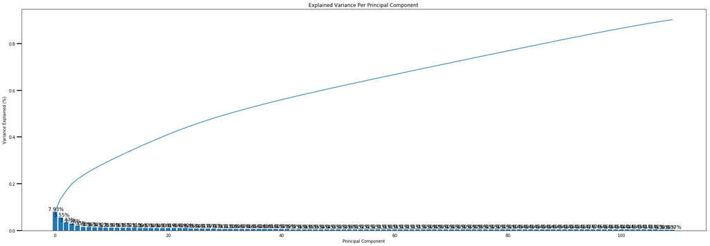

```python
# Investigate the variance accounted for by each principal component.

pca_obj, azdias_pca, retained_var = analyze(110, azdias_feat_scale)
```

```python
#Observations from multiple runs
Retained_variance_dict = {150: 0.988, 120: 0.937, 110: 0.902, 100: 0.859 }
azdias_pca.shape
```

```
(797426, 110)
```

```python
# Re-apply PCA to the data while selecting for number of components to retain.

pca_obj, azdias_pca, retained_var = analyze(110, azdias_feat_scale)
```

[output not shown]

```python
save_pca = (pca_obj, azdias_pca, retained_var)
pickle.dump(save_pca, open("pca_output.pkl", 'wb'))
```

### Discussion 2.2: Perform Dimensionality Reduction

### PCA is performed on the preprocessed data muliple times with different number of principal components to check for an optimum number to retain maximum possible variance. As the accuracy of the model is of high importance, we can't allow the model to lose more than 10% of variance. With 110 components, 90% of variance is retained and the variance contribution from each component is viewed in the Scree plot.

```python
pca_obj, azdias_pca, retained_var = pickle.load(open("pca_output.pkl", 'rb'))
```

### Step 2.3: Interpret Principal Components

Now that we have our transformed principal components, it's a nice idea to check out the weight of each variable on the first few components to see if they can be interpreted in some fashion.

As a reminder, each principal component is a unit vector that points in the direction of highest variance (after accounting for the variance captured by earlier principal components). The further a weight is from zero, the more the principal component is in the direction of the corresponding feature. If two features have large weights of the same sign (both positive or both negative), then increases in one tend expect to be associated with increases in the other. To contrast, features with different signs can be expected to show a negative correlation: increases in one variable should result in a decrease in the other.

- To investigate the features, you should map each weight to their corresponding feature name, then sort the features according to weight. The most interesting features for each principal component, then, will be those at the beginning and end of the sorted list. Use the data dictionary document to help you understand these most prominent features, their relationships, and what a positive or negative value on the principal component might indicate.
- You should investigate and interpret feature associations from the first three principal components in this substep. To help facilitate this, you should write a function that you can call at any time to print the sorted list of feature weights, for the *i*-th principal component. This might come in handy in the next step of the project, when you interpret the tendencies of the discovered clusters.

```python
pca_obj.components_.shape
# Each row is a component, which has respective weights for each of the original 201 features.
```

```
(110, 200)
```

```python
# Map weights for the first principal component to corresponding feature names
# and then print the linked values, sorted by weight.
# HINT: Try defining a function here or in a new cell that you can reuse in the other cells.
def k_component_sorted(pca, k, features = azdias_feat_scale.columns):
    component = pd.DataFrame(pca_obj.components_[k-1:k], columns=features)
    return component.sort_values(by=0, ascending=False, axis=1)

# First Component
component_1 = k_component_sorted(pca_obj, 1)
component_1
```

|  | LP_STATUS_GROB_1.0 | HH_EINKOMMEN_SCORE | CAMEO_INTL_2015_Wealth | PLZ8_ANTG3 | PLZ8_ANTG4 | ORTSGR_KLS9 | EWDICHTE | FINANZ_HAUSBAUER | WOHNLAGE_urban | LP_STATUS_FEIN_1.0 | KBA05_ANTG4 | PLZ8_ANTG2 | KBA05_ANTG3 | ARBEIT | ANZ_HAUSHALTE_AKTIV | CAMEO_DEUG_2015_9.0 | PLZ8_BAUMAX_business | LP_STATUS_FEIN_2.0 | RELAT_AB | FINANZTYP_1.0 | FINANZ_SPARER | CAMEO_DEUG_2015_8.0 | PRAEGENDE_JUGENDJAHRE_MOVEMENT_Mainstream | LP_FAMILIE_FEIN_1.0 | LP_FAMILIE_GROB_1.0 | SEMIO_PFLICHT | SEMIO_REL | ZABEOTYP_5.0 | PRAEGENDE_JUGENDJAHRE_DECADE | … |
| --- | --- | --- | --- | --- | --- | --- | --- | --- | --- | --- | --- | --- | --- | --- | --- | --- | --- | --- | --- | --- | --- | --- | --- | --- | --- | --- | --- | --- | --- | --- |
| 0 | 0.193223 | 0.181589 | 0.181374 | 0.180857 | 0.175253 | 0.158283 | 0.155453 | 0.146553 | 0.13741 | 0.128053 | 0.127823 | 0.12406 | 0.115275 | 0.115265 | 0.114422 | 0.112433 | 0.111712 | 0.111151 | 0.108592 | 0.106638 | 0.106594 | 0.091549 | 0.086549 | 0.084393 | 0.084393 | 0.076726 | 0.072468 | 0.072217 | 0.069817 | … |

```python
# Map weights for the second principal component to corresponding feature names
# and then print the linked values, sorted by weight.

component_2 = k_component_sorted(pca_obj, 2)
component_2
```

|  | ALTERSKATEGORIE_GROB | FINANZ_VORSORGER | ZABEOTYP_3.0 | SEMIO_ERL | SEMIO_LUST | RETOURTYP_BK_S | W_KEIT_KIND_HH | CJT_GESAMTTYP_2.0 | FINANZTYP_5.0 | FINANZ_MINIMALIST | FINANZTYP_2.0 | LP_STATUS_FEIN_1.0 | FINANZ_HAUSBAUER | SHOPPER_TYP_3.0 | CJT_GESAMTTYP_1.0 | SEMIO_KRIT | NATIONALITAET_KZ_1.0 | FINANZTYP_6.0 | EWDICHTE | ORTSGR_KLS9 | PLZ8_ANTG3 | GFK_URLAUBERTYP_4.0 | PLZ8_ANTG4 | WOHNDAUER_2008 | SEMIO_KAEM | LP_FAMILIE_GROB_1.0 | LP_FAMILIE_FEIN_1.0 | CAMEO_INTL_2015_Wealth | LP_STATUS_FEIN_3.0 | … |
| --- | --- | --- | --- | --- | --- | --- | --- | --- | --- | --- | --- | --- | --- | --- | --- | --- | --- | --- | --- | --- | --- | --- | --- | --- | --- | --- | --- | --- | --- | --- |
| 0 | 0.235192 | 0.221743 | 0.200163 | 0.180362 | 0.164398 | 0.154853 | 0.119291 | 0.109606 | 0.099105 | 0.095113 | 0.094124 | 0.092747 | 0.081125 | 0.075598 | 0.071107 | 0.07054 | 0.070096 | 0.067967 | 0.062622 | 0.062111 | 0.0599 | 0.058726 | 0.058702 | 0.05678 | 0.055535 | 0.05416 | 0.05416 | 0.051291 | 0.050711 | … |

```python
# Map weights for the third principal component to corresponding feature names
# and then print the linked values, sorted by weight.

component_3 = k_component_sorted(pca_obj, 3)
component_3
```

|  | SEMIO_VERT | SEMIO_SOZ | SEMIO_FAM | SEMIO_KULT | FINANZTYP_5.0 | PRAEGENDE_JUGENDJAHRE_MOVEMENT_Avantgarde | GREEN_AVANTGARDE | ZABEOTYP_1.0 | FINANZ_MINIMALIST | SHOPPER_TYP_0.0 | SEMIO_REL | LP_STATUS_GROB_5.0 | LP_STATUS_FEIN_10.0 | ORTSGR_KLS9 | EWDICHTE | SEMIO_MAT | RETOURTYP_BK_S | WOHNLAGE_urban | PLZ8_ANTG3 | PLZ8_ANTG4 | LP_STATUS_FEIN_3.0 | PLZ8_BAUMAX_business | RELAT_AB | SHOPPER_TYP_1.0 | PLZ8_ANTG2 | ZABEOTYP_6.0 | ARBEIT | LP_STATUS_GROB_3.0 | W_KEIT_KIND_HH | … |
| --- | --- | --- | --- | --- | --- | --- | --- | --- | --- | --- | --- | --- | --- | --- | --- | --- | --- | --- | --- | --- | --- | --- | --- | --- | --- | --- | --- | --- | --- | --- |
| 0 | 0.296381 | 0.24252 | 0.242159 | 0.232931 | 0.14187 | 0.137459 | 0.137459 | 0.12638 | 0.126295 | 0.110726 | 0.108048 | 0.102826 | 0.102826 | 0.100329 | 0.098965 | 0.085995 | 0.070133 | 0.061411 | 0.061316 | 0.060763 | 0.055641 | 0.054735 | 0.049348 | 0.047482 | 0.046844 | 0.044554 | 0.043728 | 0.040895 | 0.040623 | … |

## Step 3: Clustering

### Step 3.1: Apply Clustering to General Population

You've assessed and cleaned the demographics data, then scaled and transformed them. Now, it's time to see how the data clusters in the principal components space. In this substep, you will apply k-means clustering to the dataset and use the average within-cluster distances from each point to their assigned cluster's centroid to decide on a number of clusters to keep.

- Use sklearn's KMeans class to perform k-means clustering on the PCA-transformed data.
- Then, compute the average difference from each point to its assigned cluster's center. **Hint**: The KMeans object's `.score()` method might be useful here, but note that in sklearn, scores tend to be defined so that larger is better. Try applying it to a small, toy dataset, or use an internet search to help your understanding.
- Perform the above two steps for a number of different cluster counts. You can then see how the average distance decreases with an increasing number of clusters. However, each additional cluster provides a smaller net benefit. Use this fact to select a final number of clusters in which to group the data. **Warning**: because of the large size of the dataset, it can take a long time for the algorithm to resolve. The more clusters to fit, the longer the algorithm will take. You should test for cluster counts through at least 10 clusters to get the full picture, but you shouldn't need to test for a number of clusters above about 30.
- Once you've selected a final number of clusters to use, re-fit a KMeans instance to perform the clustering operation. Make sure that you also obtain the cluster assignments for the general demographics data, since you'll be using them in the final Step 3.3.

```python
# Over a number of different cluster counts...
def cluster_n(data, n_start, n_stop):
    '''Function - Compute KMeans Clustering with number of clusters mentioned in specific range and plots the Elbow plot
        Input - cleaned PCA data to be clustered, starting and ending range for number of clusters
        Ouput - Plot Elbow graph and return the scores for the runs'''
    score = []
    for i in range(n_start, n_stop+1):
        model = KMeans(n_clusters=i)
        model_fit = model.fit(data)
        score.append(np.abs(model.score(data)))
    plt.plot(range(n_start, n_stop+1), score)
    return score
```

```python
# Investigate the change in within-cluster distance across number of clusters.
# HINT: Use matplotlib's plot function to visualize this relationship.
```

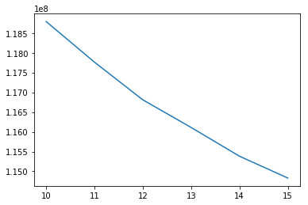

```python
score_10_15 = cluster_n(azdias_pca, 10, 15)
```

```python
kmeans = KMeans()
kmeans_fit = kmeans.fit(azdias_pca)
score = kmeans.score(azdias_pca)
score
```

```
-120709063.03208147
```

```python
score_10_15
```

```
[118790281.19640687,
 117762603.8992997,
 116809741.43425769,
 116110268.42988369,
 115383297.00711381,
 114830717.16134486]
```

[output not shown]

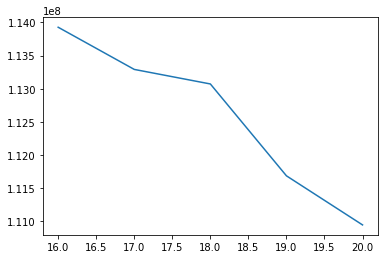

```python
score_16_20 = cluster_n(azdias_pca, 16, 20)
score_16_20
```

[output not shown]

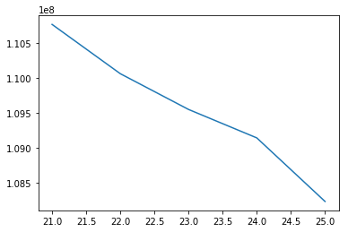

```python
score_21_25 = cluster_n(azdias_pca, 21, 25)
score_21_25
```

[output not shown]

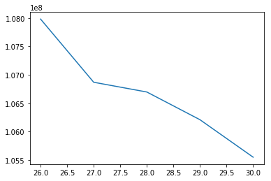

```python
score_26_30 = cluster_n(azdias_pca, 26, 30)
score_26_30
```

```python
# Re-fit the k-means model with the selected number of clusters and obtain
# cluster predictions for the general population demographics data.

# Choosing the cluster size as 15

kmeans_15 = KMeans(15)
kmeans_15.fit(azdias_pca)
demog_predict = kmeans_15.predict(azdias_pca)
```

```python
demog_cluster = demog_predict #Just changing name for better interpretation
demog_cluster
```

```
array([ 6,  8,  9, ...,  0, 13, 12], dtype=int32)
```

```python
save_models = (imputer, std_scaler, pca_obj, kmeans_15)
pickle.dump(save_models, open("model_objects.pkl", 'wb'))
```

### Step 3.2: Apply All Steps to the Customer Data

Now that you have clusters and cluster centers for the general population, it's time to see how the customer data maps on to those clusters. Take care to not confuse this for re-fitting all of the models to the customer data. Instead, you're going to use the fits from the general population to clean, transform, and cluster the customer data. In the last step of the project, you will interpret how the general population fits apply to the customer data.

- Don't forget when loading in the customers data, that it is semicolon (`;`) delimited.
- Apply the same feature wrangling, selection, and engineering steps to the customer demographics using the `clean_data()` function you created earlier. (You can assume that the customer demographics data has similar meaning behind missing data patterns as the general demographics data.)
- Use the sklearn objects from the general demographics data, and apply their transformations to the customers data. That is, you should not be using a `.fit()` or `.fit_transform()` method to re-fit the old objects, nor should you be creating new sklearn objects! Carry the data through the feature scaling, PCA, and clustering steps, obtaining cluster assignments for all of the data in the customer demographics data.

```python
imputer, std_scaler, pca_obj, kmeans_15 = pickle.load(open("model_objects.pkl", 'rb'))
```

```python
# Load in the customer demographics data.
customers = pd.DataFrame(pd.read_csv('Udacity_CUSTOMERS_Subset.csv', delimiter=';'))
customers.shape
customers.head()
```

```
(191652, 85)
```

|  | AGER_TYP | ALTERSKATEGORIE_GROB | ANREDE_KZ | CJT_GESAMTTYP | FINANZ_MINIMALIST | FINANZ_SPARER | FINANZ_VORSORGER | FINANZ_ANLEGER | FINANZ_UNAUFFAELLIGER | FINANZ_HAUSBAUER | FINANZTYP | GEBURTSJAHR | GFK_URLAUBERTYP | GREEN_AVANTGARDE | HEALTH_TYP | LP_LEBENSPHASE_FEIN | LP_LEBENSPHASE_GROB | LP_FAMILIE_FEIN | LP_FAMILIE_GROB | LP_STATUS_FEIN | LP_STATUS_GROB | NATIONALITAET_KZ | PRAEGENDE_JUGENDJAHRE | RETOURTYP_BK_S | SEMIO_SOZ | SEMIO_FAM | SEMIO_REL | SEMIO_MAT | SEMIO_VERT | … |
| --- | --- | --- | --- | --- | --- | --- | --- | --- | --- | --- | --- | --- | --- | --- | --- | --- | --- | --- | --- | --- | --- | --- | --- | --- | --- | --- | --- | --- | --- | --- |
| 0 | 2 | 4 | 1 | 5.0 | 5 | 1 | 5 | 1 | 2 | 2 | 2 | 0 | 4.0 | 1 | 1 | 20.0 | 5.0 | 2.0 | 2.0 | 10.0 | 5.0 | 1 | 4 | 5.0 | 6 | 5 | 2 | 6 | 6 | … |
| 1 | -1 | 4 | 1 | NaN | 5 | 1 | 5 | 1 | 3 | 2 | 2 | 0 | NaN | 0 | 1 | NaN | NaN | NaN | NaN | NaN | NaN | 1 | 0 | NaN | 3 | 6 | 2 | 6 | 7 | … |
| 2 | -1 | 4 | 2 | 2.0 | 5 | 1 | 5 | 1 | 4 | 4 | 2 | 0 | 3.0 | 1 | 2 | 13.0 | 3.0 | 1.0 | 1.0 | 10.0 | 5.0 | 1 | 4 | 5.0 | 2 | 2 | 1 | 3 | 3 | … |
| 3 | 1 | 4 | 1 | 2.0 | 5 | 1 | 5 | 2 | 1 | 2 | 6 | 0 | 10.0 | 0 | 2 | 0.0 | 0.0 | 0.0 | 0.0 | 9.0 | 4.0 | 1 | 1 | 3.0 | 6 | 5 | 3 | 4 | 7 | … |
| 4 | -1 | 3 | 1 | 6.0 | 3 | 1 | 4 | 4 | 5 | 2 | 2 | 1960 | 2.0 | 0 | 3 | 31.0 | 10.0 | 10.0 | 5.0 | 1.0 | 1.0 | 1 | 8 | 5.0 | 4 | 5 | 4 | 6 | 5 | … |

```python
# Apply preprocessing, feature transformation, and clustering from the general
# demographics onto the customer data, obtaining cluster predictions for the
# customer demographics data.
feat_info_old = pd.read_csv('AZDIAS_Feature_Summary.csv', delimiter=';')
customer_cleaned = clean_data(customers, feat_info_old)
customer_cleaned.shape
customer_cleaned.head()
```

```
Dropped the 6 columns
Dropped the rows having more null values
Encoded OST_WEST_KZ column
One Hot Encoding DONE
Mapping Mixed variables DONE
One Hot Encoding mixed variables done
```

```
(141640, 199)
```

|  | ALTERSKATEGORIE_GROB | ANREDE_KZ | FINANZ_MINIMALIST | FINANZ_SPARER | FINANZ_VORSORGER | FINANZ_ANLEGER | FINANZ_UNAUFFAELLIGER | FINANZ_HAUSBAUER | GREEN_AVANTGARDE | HEALTH_TYP | RETOURTYP_BK_S | SEMIO_SOZ | SEMIO_FAM | SEMIO_REL | SEMIO_MAT | SEMIO_VERT | SEMIO_LUST | SEMIO_ERL | SEMIO_KULT | SEMIO_RAT | SEMIO_KRIT | SEMIO_DOM | SEMIO_KAEM | SEMIO_PFLICHT | SEMIO_TRADV | SOHO_KZ | VERS_TYP | ANZ_PERSONEN | ANZ_TITEL | … |
| --- | --- | --- | --- | --- | --- | --- | --- | --- | --- | --- | --- | --- | --- | --- | --- | --- | --- | --- | --- | --- | --- | --- | --- | --- | --- | --- | --- | --- | --- | --- |
| 0 | 4.0 | 1.0 | 5.0 | 1.0 | 5.0 | 1.0 | 2.0 | 2.0 | 1 | 1.0 | 5.0 | 6.0 | 5.0 | 2.0 | 6.0 | 6.0 | 7.0 | 3.0 | 4.0 | 1.0 | 3.0 | 1.0 | 1.0 | 2.0 | 1.0 | 0.0 | 1.0 | 2.0 | 0.0 | … |
| 1 | 4.0 | 2.0 | 5.0 | 1.0 | 5.0 | 1.0 | 4.0 | 4.0 | 1 | 2.0 | 5.0 | 2.0 | 2.0 | 1.0 | 3.0 | 3.0 | 7.0 | 7.0 | 1.0 | 2.0 | 7.0 | 5.0 | 6.0 | 4.0 | 1.0 | 0.0 | 2.0 | 1.0 | 0.0 | … |
| 2 | 4.0 | 1.0 | 5.0 | 1.0 | 5.0 | 2.0 | 1.0 | 2.0 | 0 | 2.0 | 3.0 | 6.0 | 5.0 | 3.0 | 4.0 | 7.0 | 5.0 | 3.0 | 4.0 | 3.0 | 3.0 | 3.0 | 3.0 | 3.0 | 4.0 | 0.0 | 1.0 | 0.0 | 0.0 | … |
| 3 | 3.0 | 1.0 | 3.0 | 1.0 | 4.0 | 4.0 | 5.0 | 2.0 | 0 | 3.0 | 5.0 | 4.0 | 5.0 | 4.0 | 6.0 | 5.0 | 6.0 | 4.0 | 5.0 | 5.0 | 3.0 | 5.0 | 2.0 | 5.0 | 4.0 | 0.0 | 2.0 | 4.0 | 0.0 | … |
| 4 | 3.0 | 1.0 | 5.0 | 1.0 | 5.0 | 1.0 | 2.0 | 3.0 | 1 | 3.0 | 3.0 | 6.0 | 4.0 | 4.0 | 1.0 | 7.0 | 6.0 | 4.0 | 6.0 | 2.0 | 5.0 | 5.0 | 3.0 | 3.0 | 4.0 | 0.0 | 2.0 | 2.0 | 0.0 | … |

when did the same preprocessing for Azdias Demographic data, I had 200 columns, 1 column is missing

```python
set(azdias.columns) - set(customer_cleaned.columns)
# ['GEBAEUDETYP_5.0'] column is missing, for the rest ones, [CAMEO_DEUG_2015_1.0] is present in the other one as [CAMEO_DEUG_2015_1]
# due to int and float
```

```
{'CAMEO_DEUG_2015_1.0',
 'CAMEO_DEUG_2015_2.0',
 'CAMEO_DEUG_2015_3.0',
 'CAMEO_DEUG_2015_4.0',
 'CAMEO_DEUG_2015_5.0',
 'CAMEO_DEUG_2015_6.0',
 'CAMEO_DEUG_2015_7.0',
 'CAMEO_DEUG_2015_8.0',
 'CAMEO_DEUG_2015_9.0',
 'GEBAEUDETYP_5.0'}
```

```python
customer_cleaned['GEBAEUDETYP_5.0'] = 0
```

```python
customer_cleaned.shape
```

```
(141640, 200)
```

```python
# Saving the cleaned file
customer_cleaned.to_csv('customer_cleaned')
```

```python
# Reading the cleaned file
customer_cleaned = pd.read_csv('customer_cleaned')
customer_cleaned.drop(['Unnamed: 0'], axis=1, inplace=True)
customer_cleaned.head()
customer_cleaned.shape
```

|  | ALTERSKATEGORIE_GROB | ANREDE_KZ | FINANZ_MINIMALIST | FINANZ_SPARER | FINANZ_VORSORGER | FINANZ_ANLEGER | FINANZ_UNAUFFAELLIGER | FINANZ_HAUSBAUER | GREEN_AVANTGARDE | HEALTH_TYP | RETOURTYP_BK_S | SEMIO_SOZ | SEMIO_FAM | SEMIO_REL | SEMIO_MAT | SEMIO_VERT | SEMIO_LUST | SEMIO_ERL | SEMIO_KULT | SEMIO_RAT | SEMIO_KRIT | SEMIO_DOM | SEMIO_KAEM | SEMIO_PFLICHT | SEMIO_TRADV | SOHO_KZ | VERS_TYP | ANZ_PERSONEN | ANZ_TITEL | … |
| --- | --- | --- | --- | --- | --- | --- | --- | --- | --- | --- | --- | --- | --- | --- | --- | --- | --- | --- | --- | --- | --- | --- | --- | --- | --- | --- | --- | --- | --- | --- |
| 0 | 4.0 | 1.0 | 5.0 | 1.0 | 5.0 | 1.0 | 2.0 | 2.0 | 1 | 1.0 | 5.0 | 6.0 | 5.0 | 2.0 | 6.0 | 6.0 | 7.0 | 3.0 | 4.0 | 1.0 | 3.0 | 1.0 | 1.0 | 2.0 | 1.0 | 0.0 | 1.0 | 2.0 | 0.0 | … |
| 1 | 4.0 | 2.0 | 5.0 | 1.0 | 5.0 | 1.0 | 4.0 | 4.0 | 1 | 2.0 | 5.0 | 2.0 | 2.0 | 1.0 | 3.0 | 3.0 | 7.0 | 7.0 | 1.0 | 2.0 | 7.0 | 5.0 | 6.0 | 4.0 | 1.0 | 0.0 | 2.0 | 1.0 | 0.0 | … |
| 2 | 4.0 | 1.0 | 5.0 | 1.0 | 5.0 | 2.0 | 1.0 | 2.0 | 0 | 2.0 | 3.0 | 6.0 | 5.0 | 3.0 | 4.0 | 7.0 | 5.0 | 3.0 | 4.0 | 3.0 | 3.0 | 3.0 | 3.0 | 3.0 | 4.0 | 0.0 | 1.0 | 0.0 | 0.0 | … |
| 3 | 3.0 | 1.0 | 3.0 | 1.0 | 4.0 | 4.0 | 5.0 | 2.0 | 0 | 3.0 | 5.0 | 4.0 | 5.0 | 4.0 | 6.0 | 5.0 | 6.0 | 4.0 | 5.0 | 5.0 | 3.0 | 5.0 | 2.0 | 5.0 | 4.0 | 0.0 | 2.0 | 4.0 | 0.0 | … |
| 4 | 3.0 | 1.0 | 5.0 | 1.0 | 5.0 | 1.0 | 2.0 | 3.0 | 1 | 3.0 | 3.0 | 6.0 | 4.0 | 4.0 | 1.0 | 7.0 | 6.0 | 4.0 | 6.0 | 2.0 | 5.0 | 5.0 | 3.0 | 3.0 | 4.0 | 0.0 | 2.0 | 2.0 | 0.0 | … |

```
(141640, 200)
```

```python
# Listing all the models created Imputer, PCA, Standard Scaler, KMeans
# Imputer --> impute
# Standard Scaler --> std_scaler
# PCA --> pca_obj
# KMeans --> kmeans_15
```

```python
imputer, std_scaler, pca_obj, kmeans_15 = pickle.load(open("model_objects.pkl", 'rb'))
```

```python
kmeans_15
```

```
KMeans(algorithm='auto', copy_x=True, init='k-means++', max_iter=300,
    n_clusters=15, n_init=10, n_jobs=1, precompute_distances='auto',
    random_state=None, tol=0.0001, verbose=0)
```

```python
# Filling Null values
customer_imputed = imputer.transform(customer_cleaned)
```

```python
#Standard Scaling
customer_scaled_values = std_scaler.transform(customer_imputed)
customer_scaled_values
```

```
array([[ 1.18405078, -1.04376452,  1.40906944, ...,  4.72346238,
        -1.67348211, -0.47570389],
       [ 1.18405078,  0.9580705 ,  1.40906944, ...,  4.72346238,
        -1.67348211, -0.47570389],
       [ 1.18405078, -1.04376452,  1.40906944, ...,  4.72346238,
        -1.67348211, -0.47570389],
       ...,
       [ 1.18405078, -1.04376452,  1.40906944, ...,  4.72346238,
        -1.67348211, -0.47570389],
       [ 0.20058927,  0.9580705 , -0.76868968, ...,  4.72346238,
        -1.67348211, -0.47570389],
       [-0.78287224, -1.04376452,  1.40906944, ...,  4.72346238,
        -1.67348211, -0.47570389]])
```

```python
# Converting the scaled data to a DataFrame
customer_scaled = pd.DataFrame(customer_scaled_values, index=customer_cleaned.index, columns=customer_cleaned.columns)
customer_scaled.head()
customer_scaled.shape
```

|  | ALTERSKATEGORIE_GROB | ANREDE_KZ | FINANZ_MINIMALIST | FINANZ_SPARER | FINANZ_VORSORGER | FINANZ_ANLEGER | FINANZ_UNAUFFAELLIGER | FINANZ_HAUSBAUER | GREEN_AVANTGARDE | HEALTH_TYP | RETOURTYP_BK_S | SEMIO_SOZ | SEMIO_FAM | SEMIO_REL | SEMIO_MAT | SEMIO_VERT | SEMIO_LUST | SEMIO_ERL | SEMIO_KULT | SEMIO_RAT | SEMIO_KRIT | SEMIO_DOM | SEMIO_KAEM | SEMIO_PFLICHT | SEMIO_TRADV | SOHO_KZ | VERS_TYP | ANZ_PERSONEN | ANZ_TITEL | … |
| --- | --- | --- | --- | --- | --- | --- | --- | --- | --- | --- | --- | --- | --- | --- | --- | --- | --- | --- | --- | --- | --- | --- | --- | --- | --- | --- | --- | --- | --- | --- |
| 0 | 1.184051 | -1.043765 | 1.409069 | -1.155304 | 1.137960 | -1.249881 | -0.469752 | -0.792034 | 1.884775 | -1.633717 | 1.063959 | 0.957900 | 0.463466 | -1.043706 | 1.104338 | 0.885562 | 1.267817 | -0.888119 | -0.067639 | -1.750402 | -0.880050 | -1.946174 | -1.763643 | -1.177846 | -1.543203 | -0.092133 | -1.083385 | 0.233996 | -0.06057 | … |
| 1 | 1.184051 | 0.958071 | 1.409069 | -1.155304 | 1.137960 | -1.249881 | 0.959677 | 0.628533 | 1.884775 | -0.311674 | 1.063959 | -1.102885 | -1.104235 | -1.567205 | -0.463478 | -0.656891 | 1.267817 | 1.301605 | -1.599828 | -1.145482 | 1.392858 | 0.244076 | 0.913247 | -0.099402 | -1.543203 | -0.092133 | 0.923033 | -0.630760 | -0.06057 | … |
| 2 | 1.184051 | -1.043765 | 1.409069 | -1.155304 | 1.137960 | -0.570799 | -1.184467 | -0.792034 | -0.530567 | -0.311674 | -0.310529 | 0.957900 | 0.463466 | -0.520206 | 0.059127 | 1.399712 | 0.316750 | -0.888119 | -0.067639 | -0.540563 | -0.880050 | -0.851049 | -0.692887 | -0.638624 | 0.155902 | -0.092133 | -1.083385 | -1.495517 | -0.06057 | … |
| 3 | 0.200589 | -1.043765 | -0.042770 | -1.155304 | 0.411731 | 0.787366 | 1.674391 | -0.792034 | -0.530567 | 1.010368 | 1.063959 | -0.072493 | 0.463466 | 0.003294 | 1.104338 | 0.371411 | 0.792283 | -0.340688 | 0.443091 | 0.669276 | -0.880050 | 0.244076 | -1.228265 | 0.439820 | 0.155902 | -0.092133 | 0.923033 | 1.963509 | -0.06057 | … |
| 4 | 0.200589 | -1.043765 | 1.409069 | -1.155304 | 1.137960 | -1.249881 | -0.469752 | -0.081750 | 1.884775 | 1.010368 | -0.310529 | 0.957900 | -0.059101 | 0.003294 | -1.508689 | 1.399712 | 0.792283 | -0.340688 | 0.953820 | -1.145482 | 0.256404 | 0.244076 | -0.692887 | -0.638624 | 0.155902 | -0.092133 | 0.923033 | 0.233996 | -0.06057 | … |

```
(141640, 200)
```

```python
# Applying PCA
customer_pca = pca_obj.transform(customer_scaled)
customer_pca.shape
```

```
(141640, 110)
```

```python
# Predicting the Clusters
customer_cluster = kmeans_15.predict(customer_pca)
```

```python
kmeans_15.cluster_centers_[0]
```

```
array([ -9.40662016e-01,  -3.83606753e+00,  -1.84602382e+00,
        -1.71248630e+00,  -1.67732647e+00,   1.72117693e+00,
        -4.64853754e-02,  -8.32576190e-01,   4.66803605e-01,
        -6.56099569e-01,  -1.02577217e+00,   4.03287553e-01,
         7.14075426e-02,  -2.32949348e-01,  -1.08897333e-01,
        -4.35612628e-01,  -2.78606398e-01,  -4.85135283e-01,
        -5.82295614e-01,   1.68444497e-01,   2.77946437e-01,
         1.56897212e-01,  -6.94751969e-02,   1.21700339e-01,
        -5.44779739e-01,  -4.26472489e-01,   1.15743191e-01,
        -5.53683674e-02,  -6.18133844e-02,   4.08268597e-01,
        -2.53637959e-01,   4.25415521e-01,   2.18312036e-01,
         1.41993504e-01,  -5.72080149e-01,   3.92036875e-01,
         2.20317631e-01,   8.93276664e-03,  -3.54480715e-01,
         1.71485671e-01,   1.38667002e-02,   8.63466113e-02,
        -7.52465934e-02,   1.78788405e-01,   7.01279504e-02,
         9.33926243e-02,   1.04267703e-01,   8.02650711e-02,
         6.77158929e-02,  -4.29835173e-02,   1.23661533e-01,
         1.28872381e-01,   2.89601444e-01,  -2.19853039e-01,
         3.47615448e-01,   8.63870633e-02,   1.33895164e-01,
         9.43478154e-02,   1.18526864e-01,  -1.23800726e-01,
        -5.05944035e-02,  -7.03221985e-02,  -1.29411662e-01,
         1.21692660e-01,   1.25170472e-02,   7.26685935e-02,
        -1.72243175e-01,   2.73938713e-02,  -1.47736111e-02,
        -6.98775310e-02,  -7.43591044e-02,  -9.77176869e-02,
        -2.38518179e-02,  -3.66008232e-03,  -7.92137298e-02,
        -7.32778796e-02,   8.40212275e-03,  -1.54364933e-02,
        -1.41673897e-02,   5.72793587e-02,   3.88704752e-02,
        -1.31176571e-02,  -1.26894356e-02,  -4.22822313e-02,
         3.99556272e-02,   1.45217656e-01,   2.79967032e-02,
         6.96506923e-02,  -4.66170780e-03,  -9.09135618e-02,
        -9.60639518e-02,  -1.70160250e-01,   1.52942139e-02,
        -7.84293193e-02,  -2.22684177e-02,  -2.67307591e-01,
        -1.07540869e-01,   5.38996795e-01,   2.49541995e-01,
         3.00392128e-01,  -1.74814354e-01,   2.71710176e-01,
         3.35982818e-01,   1.65161797e-01,   7.00854909e-02,
         1.12013933e-01,  -3.34603596e-01,  -2.75724023e-02,
        -2.73834342e-01,   5.36028644e-02])
```

### Step 3.3: Compare Customer Data to Demographics Data

At this point, you have clustered data based on demographics of the general population of Germany, and seen how the customer data for a mail-order sales company maps onto those demographic clusters. In this final substep, you will compare the two cluster distributions to see where the strongest customer base for the company is.

Consider the proportion of persons in each cluster for the general population, and the proportions for the customers. If we think the company's customer base to be universal, then the cluster assignment proportions should be fairly similar between the two. If there are only particular segments of the population that are interested in the company's products, then we should see a mismatch from one to the other. If there is a higher proportion of persons in a cluster for the customer data compared to the general population (e.g. 5% of persons are assigned to a cluster for the general population, but 15% of the customer data is closest to that cluster's centroid) then that suggests the people in that cluster to be a target audience for the company. On the other hand, the proportion of the data in a cluster being larger in the general population than the customer data (e.g. only 2% of customers closest to a population centroid that captures 6% of the data) suggests that group of persons to be outside of the target demographics.

Take a look at the following points in this step:

- Compute the proportion of data points in each cluster for the general population and the customer data. Visualizations will be useful here: both for the individual dataset proportions, but also to visualize the ratios in cluster representation between groups. Seaborn's [`countplot()`](https://seaborn.pydata.org/generated/seaborn.countplot.html) or [`barplot()`](https://seaborn.pydata.org/generated/seaborn.barplot.html) function could be handy.
  - Recall the analysis you performed in step 1.1.3 of the project, where you separated out certain data points from the dataset if they had more than a specified threshold of missing values. If you found that this group was qualitatively different from the main bulk of the data, you should treat this as an additional data cluster in this analysis. Make sure that you account for the number of data points in this subset, for both the general population and customer datasets, when making your computations!
- Which cluster or clusters are overrepresented in the customer dataset compared to the general population? Select at least one such cluster and infer what kind of people might be represented by that cluster. Use the principal component interpretations from step 2.3 or look at additional components to help you make this inference. Alternatively, you can use the `.inverse_transform()` method of the PCA and StandardScaler objects to transform centroids back to the original data space and interpret the retrieved values directly.
- Perform a similar investigation for the underrepresented clusters. Which cluster or clusters are underrepresented in the customer dataset compared to the general population, and what kinds of people are typified by these clusters?

```python
unique1, freq1 = np.unique(customer_cluster, return_counts=True)
unique2, freq2 = np.unique(demog_cluster, return_counts=True)
```

```
Text(0.5,1,'Frequency of customers in each cluster')
```

```
Text(0.5,1,'In Count')
```

```
Text(0.5,1,'In Percentages')
```

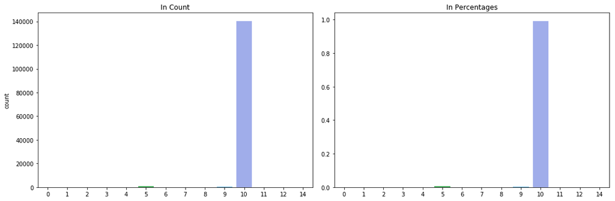

```python
# Compare the proportion of data in each cluster for the customer data to the -- customer_cluster
# proportion of data in each cluster for the general population. -- demog_cluster

# Plotting Customer clusters
fig, ax = plt.subplots(1,2, figsize=(15,5))
plt.title("Frequency of customers in each cluster")

sns.countplot(customer_cluster, ax=ax[0])
ax[0].set_title("In Count")

sns.barplot(x=unique1, y=freq1/customer_cluster.shape, ax=ax[1])
ax[1].set_title("In Percentages")
plt.tight_layout()
```

```
Text(0.5,1,'Frequency of customers in each cluster')
```

```
Text(0.5,1,'In Count')
```

```
Text(0.5,1,'In Percentages')
```

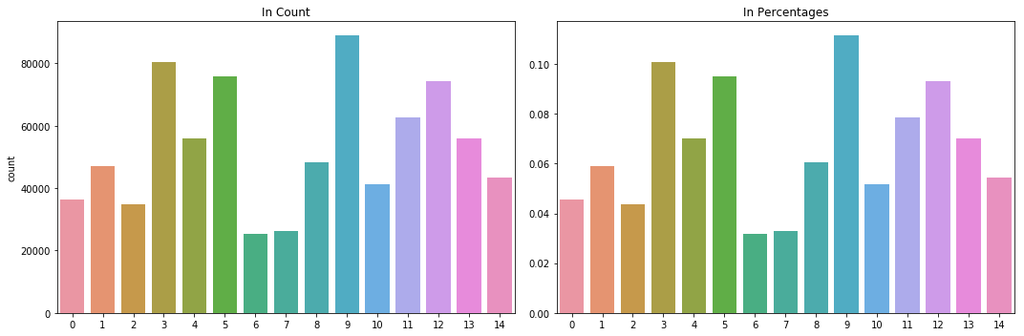

```python
# Plotting Demographic clusters
fig, ax = plt.subplots(1,2, figsize=(15,5))
plt.title("Frequency of customers in each cluster")

sns.countplot(demog_cluster, ax=ax[0])
ax[0].set_title("In Count")

sns.barplot(x=unique2, y=freq2/demog_cluster.shape, ax=ax[1])
ax[1].set_title("In Percentages")
plt.tight_layout()
```

```python
# What kinds of people are part of a cluster that is overrepresented in the
# customer data compared to the general population?

# Cluster 10 is overrepresentated in customer custers
cluster_center_10 = std_scaler.inverse_transform(pca_obj.inverse_transform(kmeans_15.cluster_centers_[10])).round(2)
cluster_center_10_std = pca_obj.inverse_transform(kmeans_15.cluster_centers_[10]).round(2)
```

```python
# Having a look at the features at centroids
cluster_10 = pd.DataFrame(data=[cluster_center_10,cluster_center_10_std], index=['feat_space','standard_scale' ], columns= customer_cleaned.columns)
#cluster_10_std = pd.Series(cluster_center_10_std)
cluster_10
```

|  | ALTERSKATEGORIE_GROB | ANREDE_KZ | FINANZ_MINIMALIST | FINANZ_SPARER | FINANZ_VORSORGER | FINANZ_ANLEGER | FINANZ_UNAUFFAELLIGER | FINANZ_HAUSBAUER | GREEN_AVANTGARDE | HEALTH_TYP | RETOURTYP_BK_S | SEMIO_SOZ | SEMIO_FAM | SEMIO_REL | SEMIO_MAT | SEMIO_VERT | SEMIO_LUST | SEMIO_ERL | SEMIO_KULT | SEMIO_RAT | SEMIO_KRIT | SEMIO_DOM | SEMIO_KAEM | SEMIO_PFLICHT | SEMIO_TRADV | SOHO_KZ | VERS_TYP | ANZ_PERSONEN | ANZ_TITEL | … |
| --- | --- | --- | --- | --- | --- | --- | --- | --- | --- | --- | --- | --- | --- | --- | --- | --- | --- | --- | --- | --- | --- | --- | --- | --- | --- | --- | --- | --- | --- | --- |
| feat_space | 2.30 | 1.55 | 1.78 | 3.74 | 2.52 | 3.29 | 2.88 | 4.09 | 0.04 | 2.49 | 3.44 | 4.62 | 4.82 | 4.94 | 4.35 | 3.79 | 3.96 | 4.14 | 4.70 | 4.57 | 4.71 | 4.79 | 4.83 | 5.16 | 4.37 | 0.01 | 1.64 | 1.33 | 0.00 | … |
| standard_scale | -0.48 | 0.05 | -0.93 | 0.69 | -0.66 | 0.31 | 0.16 | 0.69 | -0.44 | 0.34 | -0.01 | 0.25 | 0.37 | 0.50 | 0.24 | -0.25 | -0.18 | -0.26 | 0.29 | 0.41 | 0.09 | 0.13 | 0.29 | 0.53 | 0.36 | -0.02 | 0.21 | -0.34 | -0.03 | … |

```python
cluster_10['SEMIO_SOZ']
```

```
feat_space        4.62
standard_scale    0.25
Name: SEMIO_SOZ, dtype: float64
```

### Over represented cluster features

### For first component:

#### 1. Social Status of low income[LP_STATUS_GROB_1.0] (0.193) ----------- centroid 0.93 - close to 1 (Low Income Earners),

#### 2. Movement Patterns [MOBI_REGIO] (-0.183) ----------------------------------- centroid 1.15 (Very high),

#### 3. Financial Topology of Minimalist [FINANZ_MINIMALIST] (-0.183) ------ centroid 1.78 (High),

#### 4. Estimated household net income[HH_EINKOMMEN_SCORE] (0.181) - centroid 5.64 (Lower income to very low income),

### For second component:

#### 3. Financial Topology of Sparer [FINANZ_SPARER], (-0.231) ------------ centroid 3.74 (Average to Low)

#### 4. Financial Topology of Vorsorger [FINANZ_VORSORGER] (0.221) -- centroid 2.52 (High to Average)

### For third component:

#### 1. Gender [ANREDE_KZ] (-0.316) --------------------------- centroid 1.55 (1-Male, 2-Female, may be both male and female as the value is almost in between 1 and 2

#### 2. Personality Typology [SEMIO_VERT] (0.295) ------- centroid 3.79 (High to Average Affinity)

#### 3. Personality Typology [SEMIO_KAEM] (-0.282) ----- centroid 4.83 (Average to Low Affinity)

#### 4. Personality Typology [SEMIO_SOZ] (0.241) --------- centroid 4.62 (Average to Low Affinity)

```python
# What kinds of people are part of a cluster that is underrepresented in the
# customer data compared to the general population?
# Choosing Cluster - 5
cluster_center_3 = std_scaler.inverse_transform(pca_obj.inverse_transform(kmeans_15.cluster_centers_[3])).round(2)
cluster_center_3_std = pca_obj.inverse_transform(kmeans_15.cluster_centers_[3]).round(2)
cluster_3 = pd.DataFrame(data = [cluster_center_3,cluster_center_3_std], index=['feat_space','standard_scale' ], columns= customer_cleaned.columns)
cluster_3
```

|  | ALTERSKATEGORIE_GROB | ANREDE_KZ | FINANZ_MINIMALIST | FINANZ_SPARER | FINANZ_VORSORGER | FINANZ_ANLEGER | FINANZ_UNAUFFAELLIGER | FINANZ_HAUSBAUER | GREEN_AVANTGARDE | HEALTH_TYP | RETOURTYP_BK_S | SEMIO_SOZ | SEMIO_FAM | SEMIO_REL | SEMIO_MAT | SEMIO_VERT | SEMIO_LUST | SEMIO_ERL | SEMIO_KULT | SEMIO_RAT | SEMIO_KRIT | SEMIO_DOM | SEMIO_KAEM | SEMIO_PFLICHT | SEMIO_TRADV | SOHO_KZ | VERS_TYP | ANZ_PERSONEN | ANZ_TITEL | … |
| --- | --- | --- | --- | --- | --- | --- | --- | --- | --- | --- | --- | --- | --- | --- | --- | --- | --- | --- | --- | --- | --- | --- | --- | --- | --- | --- | --- | --- | --- | --- |
| feat_space | 1.82 | 1.99 | 1.12 | 4.48 | 2.25 | 4.47 | 3.94 | 4.26 | 0.04 | 2.36 | 2.53 | 3.11 | 3.84 | 5.32 | 4.66 | 2.27 | 3.21 | 4.41 | 4.03 | 5.93 | 5.44 | 6.08 | 5.98 | 6.02 | 5.29 | 0.01 | 1.55 | 1.5 | -0.00 | … |
| standard_scale | -0.96 | 0.94 | -1.41 | 1.19 | -0.86 | 1.11 | 0.92 | 0.81 | -0.43 | 0.17 | -0.63 | -0.53 | -0.14 | 0.69 | 0.40 | -1.03 | -0.53 | -0.11 | -0.05 | 1.23 | 0.51 | 0.84 | 0.90 | 0.99 | 0.89 | 0.00 | 0.03 | -0.2 | -0.06 | … |

```python
cluster_3['SEMIO_SOZ']
```

```
feat_space        3.11
standard_scale   -0.53
Name: SEMIO_SOZ, dtype: float64
```

### Under represented cluster (cluster 3) features

### For first component:

#### 1. Social Status of low income[LP_STATUS_GROB_1.0] (0.193) ----------- centroid 0.93 (Low income),

#### 2. Movement Patterns [MOBI_REGIO] (-0.183) ----------------------------------- centroid 2.14 (high movement) ,

#### 3. Financial Topology of Minimalist [FINANZ_MINIMALIST] (-0.183) ------ centroid 1.12 (Very High),

#### 4. Estimated household net income[HH_EINKOMMEN_SCORE] (0.181) - centroid 5.5 (Lower income to Very low income),

### For second component:

#### 3. Financial Topology of Sparer [FINANZ_SPARER], (-0.231) ------------ centroid 4.48 (Low to very low)

#### 4. Financial Topology of Vorsorger [FINANZ_VORSORGER] (0.221) -- centroid 2.25 (High)

### For third component:

#### 1. Gender [ANREDE_KZ] (-0.316) --------------------------- centroid 1.99 (Female)

#### 2. Personality Typology [SEMIO_VERT] (0.295) ------- centroid 2.27 (Very high Affinity)

#### 3. Personality Typology [SEMIO_KAEM] (-0.282) ----- centroid 5.98 (Very low Affinity)

#### 4. Personality Typology [SEMIO_SOZ] (0.241) --------- centroid 3.11 (High Affinity)

### Discussion 3.3: Compare Customer Data to Demographics Data

Yes, we can describe the segments of the population that are popular with mail-order company. The focused cluster can be explained with various features that makes it unique, but we'll stick to a couple of features and a similar analysis can be extended out to remaining features. From the above table explaining over represented features, the population with features:

```
# 1 - Income status - Low
# 2 - Financial Topology -> Minimalist - High
                      Sparer - Average to Low
                      Vorsorger - High to average
# 3 - Movement Patterns - Very High
# 4 - Age - 30 to 60 years
# 5 - Estimated House income - Low to very low
# 6 - Personality Typology SEMIO_VERT,SEMIO_KAEM,SEMIO_SOZ at Average Affinities
```

> Congratulations on making it this far in the project! Before you finish, make sure to check through the entire notebook from top to bottom to make sure that your analysis follows a logical flow and all of your findings are documented in **Discussion** cells. Once you've checked over all of your work, you should export the notebook as an HTML document to submit for evaluation. You can do this from the menu, navigating to **File -> Download as -> HTML (.html)**. You will submit both that document and this notebook for your project submission.

Resources:

```
# https://knowledge.udacity.com/questions/92587
# Stackoverflow
# scikit learn
# Udacity knowledge
```